# Mongolian Vowel harmony analysis code

Auromita

10/6/2021

Load packages and data, create dataframes from Lobanov normalized formant values, and make subsets for harmonic, non-harmonic, ATR harmony, rounding harmony.

(note: file paths relative to the Rproject root folder (mongolian_vowel_harmony))

```r
library(here) # sets working directory to project root folder (default for .rmd files: folder that contains the file)
library(readxl)
library(tidyverse)
library(lme4)
library(phonR)
library(effectsize)  # to get approximations of effect size from test statistics
library(lmerTest) # to get t and F values from lme model
# read in data
df <- read_excel("formant_data/formants_combined.xlsx")
str(df)
```

```
## tibble [3,011 × 47] (S3: tbl_df/tbl/data.frame)
##  $ filename    : chr [1:3011] "f01_frame_rep1" "f01_frame_rep1" "f01_frame_rep1" "f01_frame_rep1" ...
##  $ speaker     : chr [1:3011] "f01" "f01" "f01" "f01" ...
##  $ iteration   : num [1:3011] 1 1 1 1 1 1 1 1 1 1 ...
##  $ word        : chr [1:3011] "ʧ͡ʰiɮger" "ʦ͡ʊːraːr" "teɮijg" "ʦ͡aːrʊːɮ" ...
##  $ harmony_type: chr [1:3011] "ATR" "ATR" "ATR" "ATR" ...
##  $ v1          : chr [1:3011] "i" "ʊː" "e" "aː" ...
##  $ v2          : chr [1:3011] "e" "aː" "i" "ʊː" ...
##  $ f1_v1_t1    : num [1:3011] 275 480 823 751 317 ...
##  $ f2_v1_t1    : num [1:3011] 2240 1626 2455 1632 2547 ...
##  $ f1_v1_t2    : num [1:3011] 286 523 425 923 349 ...
##  $ f2_v1_t2    : num [1:3011] 2247 1413 2497 1673 2561 ...
##  $ f1_v1_t3    : num [1:3011] 281 529 362 1052 364 ...
##  $ f2_v1_t3    : num [1:3011] 2266 1288 2567 1636 2629 ...
##  $ f1_v1_t4    : num [1:3011] 265 510 355 1007 366 ...
```

[output cut: 33 more lines]

```r
# create "consonant" column (intervening consonant)
df <- df %>%
  mutate(temp = word, .after = v2) %>%
  #find the vowels in the word, replace with underscores
  mutate(temp = str_replace_all(temp, v1, "_")) %>%
  mutate(temp = str_replace_all(temp, v2, "_")) %>%
  #create column with whatever is between the underscores (intervening consonant)
  separate(temp, into = c(NA,"consonant",NA), sep = "_") %>%
  mutate_if(is.character,as.factor) %>%
  mutate(iteration = as.factor(iteration))

str(df)
```

```
## tibble [3,011 × 48] (S3: tbl_df/tbl/data.frame)
##  $ filename    : Factor w/ 52 levels "f01_frame_rep1",..: 1 1 1 1 1 1 1 1 1 1 ...
##  $ speaker     : Factor w/ 14 levels "f01","f02","f03",..: 1 1 1 1 1 1 1 1 1 1 ...
##  $ iteration   : Factor w/ 4 levels "1","2","3","4": 1 1 1 1 1 1 1 1 1 1 ...
##  $ word        : Factor w/ 59 levels "atiɮ","aʧ͡iɮ",..: 55 50 36 46 35 59 34 21 28 33 ...
##  $ harmony_type: Factor w/ 3 levels "ATR","non-harmonic",..: 1 1 1 1 1 2 1 1 2 1 ...
##  $ v1          : Factor w/ 13 levels "a","aː","e","eː",..: 5 13 3 2 3 8 3 10 1 3 ...
##  $ v2          : Factor w/ 12 levels "a","aː","e","eː",..: 3 2 5 12 11 7 3 5 6 4 ...
##  $ consonant   : Factor w/ 16 levels "g","j","jɮ","jr",..: 6 11 5 11 6 2 6 5 5 5 ...
##  $ f1_v1_t1    : num [1:3011] 275 480 823 751 317 ...
##  $ f2_v1_t1    : num [1:3011] 2240 1626 2455 1632 2547 ...
##  $ f1_v1_t2    : num [1:3011] 286 523 425 923 349 ...
##  $ f2_v1_t2    : num [1:3011] 2247 1413 2497 1673 2561 ...
##  $ f1_v1_t3    : num [1:3011] 281 529 362 1052 364 ...
##  $ f2_v1_t3    : num [1:3011] 2266 1288 2567 1636 2629 ...
```

[output cut: 34 more lines]

```r
attach(df)
# separate objects for F1 and F2 values

F1 <- cbind(f1_v1_t1,   f1_v1_t2,   f1_v1_t3,   f1_v1_t4,   f1_v1_t5,   f1_v1_t6,   f1_v1_t7,   f1_v1_t8,   f1_v1_t9,   f1_v1_t10, f1_v2_t1,    f1_v2_t2,   f1_v2_t3,   f1_v2_t4,   f1_v2_t5,   f1_v2_t6,   f1_v2_t7,   f1_v2_t8,   f1_v2_t9,   f1_v2_t10)
F2 <- cbind(f2_v1_t1,   f2_v1_t2,   f2_v1_t3,   f2_v1_t4,   f2_v1_t5,   f2_v1_t6,   f2_v1_t7,   f2_v1_t8,   f2_v1_t9,   f2_v1_t10, f2_v2_t1,    f2_v2_t2,   f2_v2_t3,   f2_v2_t4,   f2_v2_t5,   f2_v2_t6,   f2_v2_t7,   f2_v2_t8,   f2_v2_t9,   f2_v2_t10)

# new data frame with normalized formant values (formant-intrinsic normalization)

f1lobanov <- with(df,normLobanov(F1,group = speaker))
f2lobanov <- with(df,normLobanov(F2,group = speaker))
df_lobanov <- data.frame(speaker, iteration,word, harmony_type, v1, v2, consonant, f1lobanov, f2lobanov)

rm(F1, F2, f1lobanov, f2lobanov)

detach(df)


# subsets for harmonic and non-harmonic sequences
df_nhar <- filter(df_lobanov, harmony_type == "non-harmonic")
df_har <- filter(df_lobanov, harmony_type != "non-harmonic")

df_ATR <- filter(df_lobanov, harmony_type == "ATR")
df_rounding <- filter(df_lobanov, harmony_type == "rounding")
```

## Figures

```r
## plots

xlim=c(2.5,-2.5)
ylim=c(3,-2)
```

### Plots for full dataset:

V1:

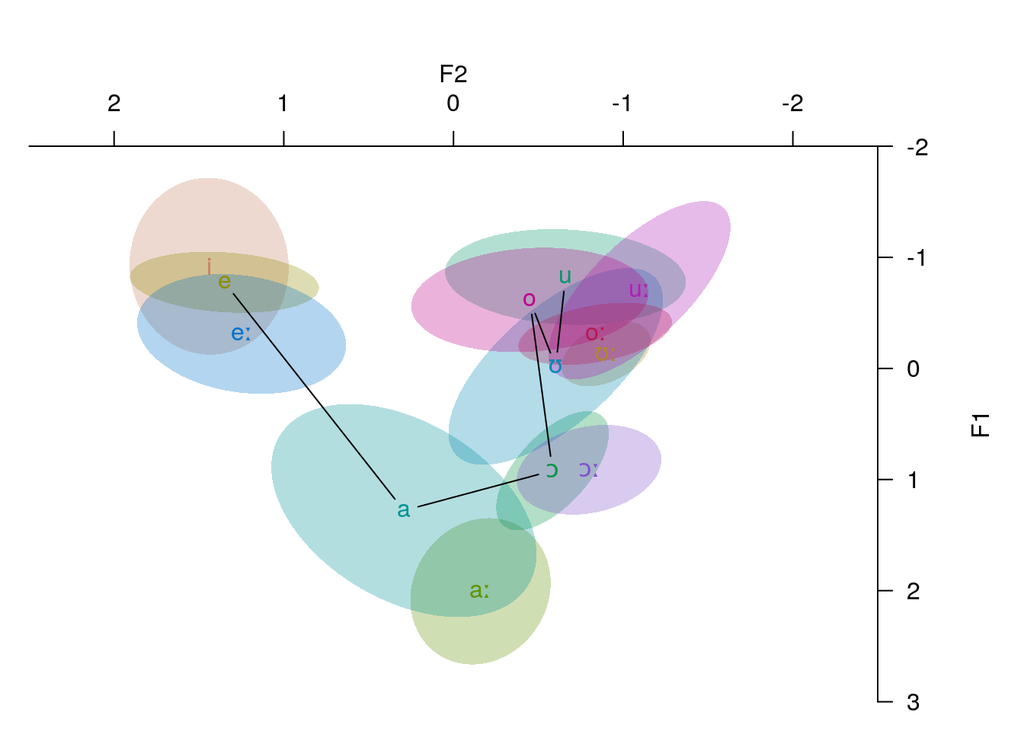

```r
with(df_lobanov, plotVowels(f1_v1_t5, f2_v1_t5,
                        xlim=xlim, ylim=ylim,
                        vowel = v1, #group = harmony_type,
                        plot.tokens = F, plot.means = T,
                        var.col.by = v1, var.sty.by = v1, pch.means = v1,
                        ellipse.fill = T, ellipse.line = F,
                        poly.line = TRUE, poly.order = c("i", "e", "a", "ɔ", "o", "ʊ", "u"),
                        pretty = T))
```

V2:

```
## [phonR]: There are vowels in 'poly.order' that are not in 'vowel'; they will be ignored.
```

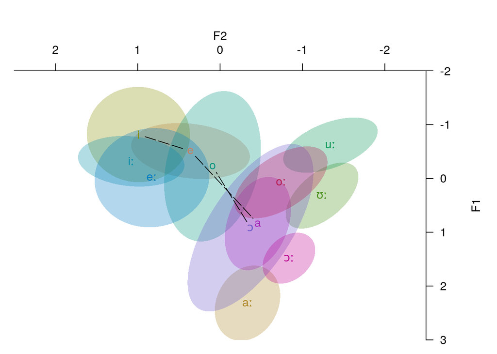

```r
with(df_lobanov, plotVowels(f1_v2_t5, f2_v2_t5,
                        xlim=xlim, ylim=ylim,
                        vowel = v2, #group = harmony_type,
                        plot.tokens = F, plot.means = T,
                        var.col.by = v2, var.sty.by = v2, pch.means = v2,
                        ellipse.fill = T, ellipse.line = F,
                        poly.line = TRUE, poly.order = c("i", "e", "a", "ɔ", "o", "ʊ", "u"),
                        pretty = T))
```

### Plots for non-harmonic sequences:

V1:

```
## [phonR]: There are vowels in 'poly.order' that are not in 'vowel'; they will be ignored.
```

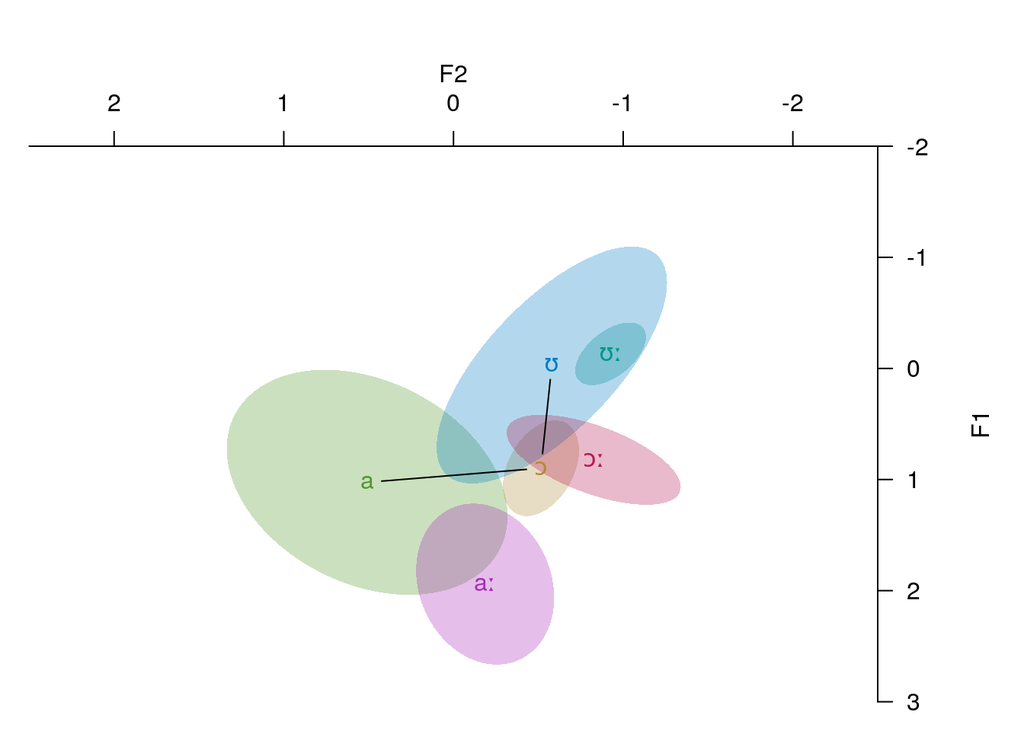

```r
with(df_nhar, plotVowels(f1_v1_t5, f2_v1_t5,
                         xlim=xlim, ylim=ylim,
                         vowel = v1, #group = speaker,
                         plot.tokens = F, plot.means = T,
                         var.col.by = v1, var.sty.by = NULL, pch.means = v1,
                         ellipse.fill = T, ellipse.line = F,
                         poly.line = T, poly.order = c("i", "e", "a", "ɔ", "o", "ʊ", "u"),
                         pretty = T))
```

V2:

```
## [phonR]: There are vowels in 'poly.order' that are not in 'vowel'; they will be ignored.
```

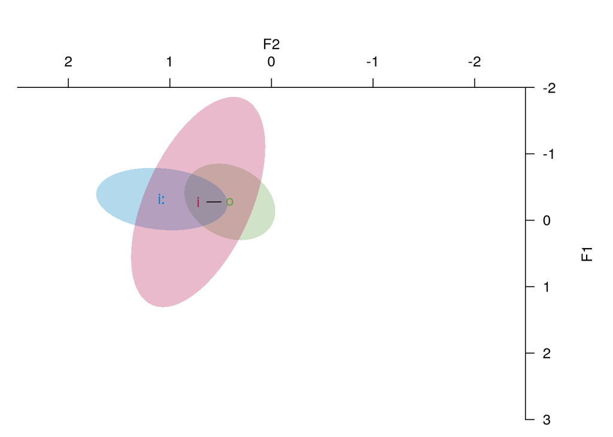

```r
with(df_nhar, plotVowels(f1_v2_t5, f2_v2_t5,
                         xlim=xlim, ylim=ylim,
                         vowel = v2, #group = speaker,
                         plot.tokens = F, plot.means = T,
                         var.col.by = v2, var.sty.by = NULL, pch.means = v2,
                         ellipse.fill = T, ellipse.line = F,
                         poly.line = T, poly.order = c("i", "e", "a", "ɔ", "o", "ʊ", "u"),
                         pretty = T))
```

```r
# figure for labphon18 abstract: diffusion in vowel space for harmonic vs non-harmonic subsets (all vowels combined: vowel=NULL)


with(df_nhar, plotVowels(f1_v1_t5, f2_v1_t5,
                         xlim=xlim, ylim=ylim,
                         vowel = NULL, #group = speaker,
                         plot.tokens = F, plot.means = T,
                         var.col.by = NULL, var.sty.by = NULL, pch.means = "V1",cex.means = 1.5,
                         ellipse.fill = T, fill.opacity = 0.3, col = "#FF6633", ellipse.line = F,
                         poly.line = T, poly.order = c("i", "e", "a", "ɔ", "o", "ʊ", "u"),
                         pretty = T))
```

```
## [phonR]: There are vowels in 'poly.order' that are not in 'vowel'; they will be ignored.
```

```
## [phonR]: There are vowels in 'poly.order' that are not in 'vowel'; they will be ignored.
```

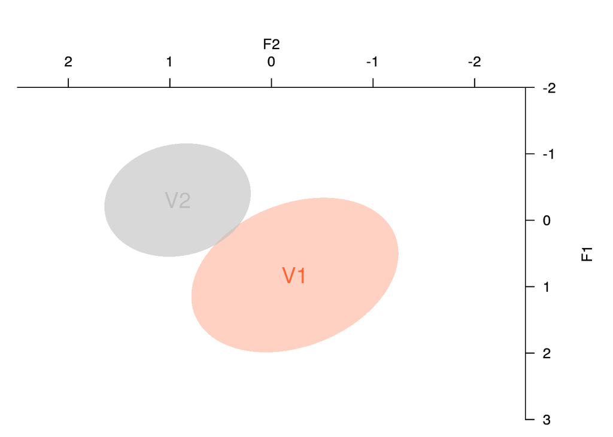

```r
par(new=TRUE)

with(df_nhar, plotVowels(f1_v2_t5, f2_v2_t5,
                         xlim=xlim, ylim=ylim,
                         vowel = NULL, #group = NULL,
                         plot.tokens = F, plot.means = T,
                         var.col.by = v2, var.sty.by = NULL, pch.means = "V2", cex.means = 1.5,
                         ellipse.fill = T, fill.opacity = 0.6, col = "grey", ellipse.line = F,
                         poly.line = T, poly.order = c("i", "e", "a", "ɔ", "o", "ʊ", "u"),
                         pretty = T))
```

### Plots for harmonic sequences:

V1:

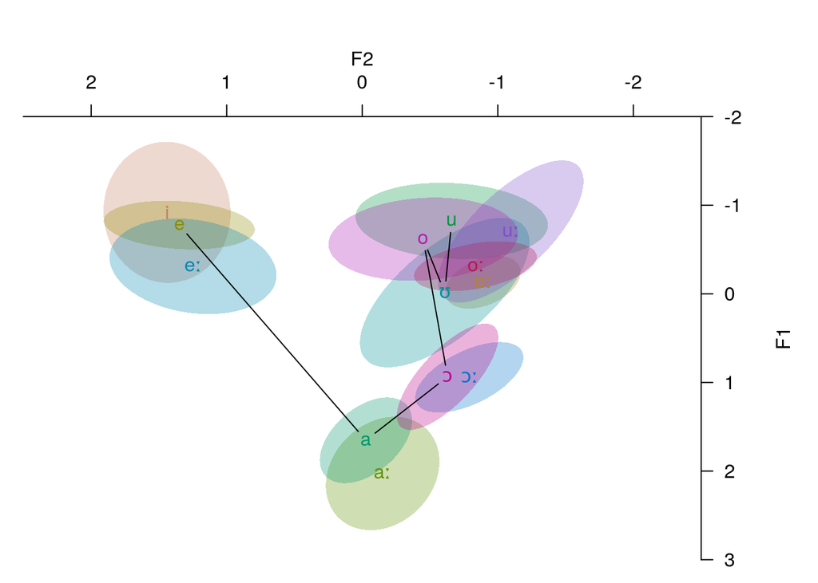

```r
with(df_har, plotVowels(f1_v1_t5, f2_v1_t5,
                        xlim=xlim, ylim=ylim,
                        vowel = v1, #group = speaker,
                        plot.tokens = FALSE, plot.means = TRUE,
                        var.col.by = v1, var.sty.by = v1, pch.means = v1,
                        ellipse.fill = T, ellipse.line = F,
                        poly.line = TRUE, poly.order = c("i", "e", "a", "ɔ", "o", "ʊ", "u"),
                        pretty = T))
```

V2:

```
## [phonR]: There are vowels in 'poly.order' that are not in 'vowel'; they will be ignored.
```

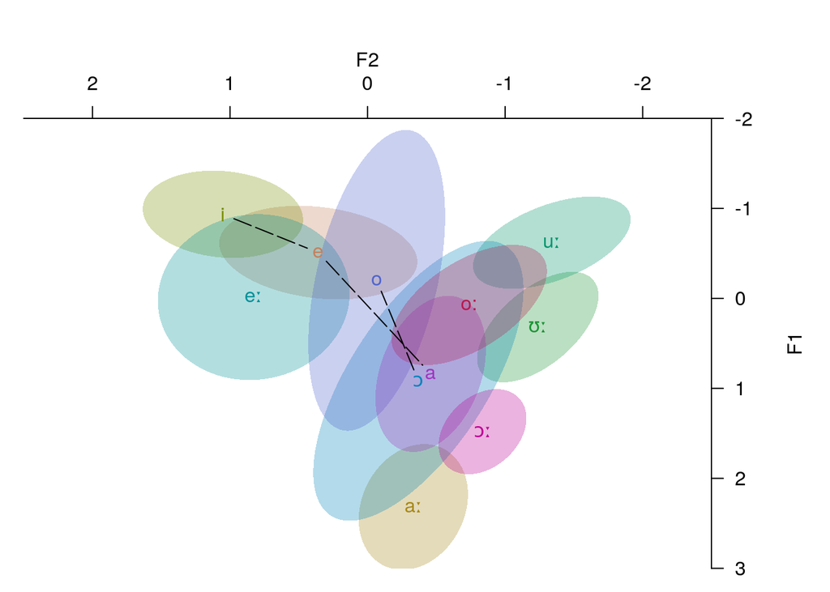

```r
with(df_har, plotVowels(f1_v2_t5, f2_v2_t5,
                        xlim=xlim, ylim=ylim,
                        vowel = v2, #group = speaker,
                        plot.tokens = F, plot.means = T,
                        var.col.by = v2, var.sty.by = v2, pch.means = v2,
                        ellipse.fill = T, ellipse.line = F,
                        poly.line = TRUE, poly.order = c("i", "e", "a", "ɔ", "o", "ʊ", "u"),
                        pretty = T))
```

```r
# figure for labphon18 abstract: diffusion in vowel space for harmonic vs non-harmonic subsets (all vowels combined: vowel=NULL)

with(df_har, plotVowels(f1_v1_t5, f2_v1_t5,
                         xlim=xlim, ylim=ylim,
                         vowel = NULL, #group = speaker,
                         plot.tokens = F, plot.means = T,
                         var.col.by = NULL, var.sty.by = NULL, pch.means = "V1",cex.means = 1.5,
                         ellipse.fill = T, fill.opacity = 0.25, col = "#FF6633", ellipse.line = F,
                         poly.line = T, poly.order = c("i", "e", "a", "ɔ", "o", "ʊ", "u"),
                         pretty = T))
```

```
## [phonR]: There are vowels in 'poly.order' that are not in 'vowel'; they will be ignored.
```

```
## [phonR]: There are vowels in 'poly.order' that are not in 'vowel'; they will be ignored.
```

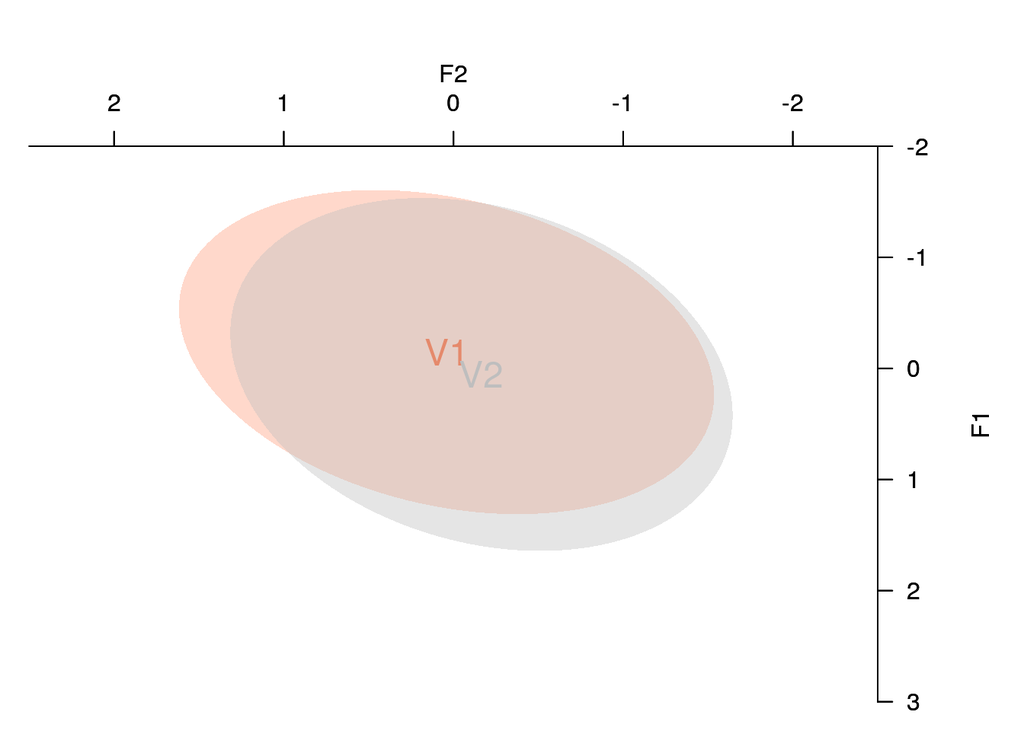

```r
par(new=TRUE)

with(df_har, plotVowels(f1_v2_t5, f2_v2_t5,
                         xlim=xlim, ylim=ylim,
                         vowel = NULL, #group = NULL,
                         plot.tokens = F, plot.means = T,
                         var.col.by = v2, var.sty.by = NULL, pch.means = "V2", cex.means = 1.5,
                         ellipse.fill = T, fill.opacity = 0.4, col = "grey", ellipse.line = F,
                         poly.line = T, poly.order = c("i", "e", "a", "ɔ", "o", "ʊ", "u"),
                         pretty = T))
```

## LME models

For linear mixed models, the data was mean-centered and scaled prior to analysis, as this increases the likelihood of convergence (Bates et al. 2015a, Eager&Roy 2017):

```r
df_lobanov.CS <- df_lobanov %>% mutate_if(is.numeric,scale)
df_har.CS <- df_har %>% mutate_if(is.numeric,scale)
df_nhar.CS <- df_nhar %>% mutate_if(is.numeric,scale)


# rm(df,df_har,df_nhar,df_rounding,df_ATR)
```

We expect that F1 of a vowel is predicted by the vowel identity. We want to test the hypothesis that F1 is also predicted by the identity of the other vowel.

Model names: - anticipatory model: v1 explained by v2 - carryover model: v2 explained by v1

Below, we compare the full models for anticipatory and carryover coarticulation to their corresponding null models.

## Models for F1

### anticipatory model (effect of v2 on v1)

```r
# full model
ant_vh.model = lmer(f1_v1_t5 ~
                     v1+ v2 +
                     (1|word),
                     data = df_lobanov.CS, REML = FALSE)
summary(rePCA(ant_vh.model))
```

```
## $word
## Importance of components:
##                         [,1]
## Standard deviation     0.174
## Proportion of Variance 1.000
## Cumulative Proportion  1.000
```

```r
summary(ant_vh.model)
```

```
## Linear mixed model fit by maximum likelihood . t-tests use Satterthwaite's
##   method [lmerModLmerTest]
## Formula: f1_v1_t5 ~ v1 + v2 + (1 | word)
##    Data: df_lobanov.CS
##
##      AIC      BIC   logLik deviance df.resid
##   3102.8   3259.1  -1525.4   3050.8     2985
##
## Scaled residuals:
##     Min      1Q  Median      3Q     Max
## -5.5931 -0.4003 -0.0489  0.3264 16.0177
##
## Random effects:
##  Groups   Name        Variance Std.Dev.
##  word     (Intercept) 0.004796 0.06925
##  Residual             0.158347 0.39793
## Number of obs: 3011, groups:  word, 59
##
## Fixed effects:
##             Estimate Std. Error       df t value Pr(>|t|)
## (Intercept)  1.67052    0.07613 59.27155  21.944  < 2e-16 ***
## v1aː         0.42808    0.06754 59.67452   6.338 3.39e-08 ***
## v1e         -1.70004    0.07673 59.33847 -22.157  < 2e-16 ***
## v1eː        -1.23468    0.07672 59.30321 -16.094  < 2e-16 ***
## v1i         -1.84115    0.06814 59.23385 -27.019  < 2e-16 ***
## v1o         -1.55426    0.07113 59.14449 -21.852  < 2e-16 ***
## v1o:        -1.28308    0.08472 58.97967 -15.145  < 2e-16 ***
## v1ɔ         -0.42713    0.06721 59.66859  -6.355 3.18e-08 ***
## v1ɔː        -0.51823    0.07284 59.56557  -7.115 1.65e-09 ***
## v1u         -1.74886    0.08100 58.53943 -21.592  < 2e-16 ***
## v1uː        -1.62892    0.07670 59.24982 -21.238  < 2e-16 ***
## v1ʊ         -1.59177    0.06407 59.32456 -24.844  < 2e-16 ***
## v1ʊː        -1.71281    0.06741 59.19307 -25.410  < 2e-16 ***
## v2aː        -0.05601    0.06928 58.99885  -0.808  0.42210
## v2e         -0.67364    0.10165 59.15822  -6.627 1.14e-08 ***
## v2eː        -0.77481    0.10164 59.13403  -7.623 2.35e-10 ***
## v2i         -0.78733    0.09086 59.14553  -8.665 4.06e-12 ***
## v2iː        -0.17438    0.06681 59.03112  -2.610  0.01145 *
## v2o         -0.64829    0.09758 59.06244  -6.644 1.08e-08 ***
## v2o:        -0.69930    0.11489 58.92949  -6.087 9.31e-08 ***
## v2ɔ         -0.32683    0.09697 58.84501  -3.371  0.00133 **
## v2ɔː        -0.32627    0.09713 59.24369  -3.359  0.00137 **
## v2uː        -0.75177    0.09839 59.16763  -7.641 2.18e-10 ***
## v2ʊː        -0.12477    0.06453 58.63384  -1.934  0.05800 .
## ---
## Signif. codes:  0 '***' 0.001 '**' 0.01 '*' 0.05 '.' 0.1 ' ' 1
```

```
##
## Correlation matrix not shown by default, as p = 24 > 12.
## Use print(x, correlation=TRUE)  or
##     vcov(x)        if you need it
```

```r
# null model
ant_null.model = lmer(f1_v1_t5 ~
                       v1 +
                       (1|word),
                       data = df_lobanov.CS, REML = FALSE)
summary(rePCA(ant_null.model))
```

```
## $word
## Importance of components:
##                          [,1]
## Standard deviation     0.3504
## Proportion of Variance 1.0000
## Cumulative Proportion  1.0000
```

```r
summary(ant_null.model)
```

```
## Linear mixed model fit by maximum likelihood . t-tests use Satterthwaite's
##   method [lmerModLmerTest]
## Formula: f1_v1_t5 ~ v1 + (1 | word)
##    Data: df_lobanov.CS
##
##      AIC      BIC   logLik deviance df.resid
##   3142.7   3232.9  -1556.4   3112.7     2996
##
## Scaled residuals:
##     Min      1Q  Median      3Q     Max
## -5.6367 -0.3922 -0.0418  0.3252 15.9117
##
## Random effects:
##  Groups   Name        Variance Std.Dev.
##  word     (Intercept) 0.01944  0.1394
##  Residual             0.15835  0.3979
## Number of obs: 3011, groups:  word, 59
##
## Fixed effects:
##             Estimate Std. Error       df t value Pr(>|t|)
## (Intercept)  1.28426    0.06721 59.17710  19.109  < 2e-16 ***
## v1aː         0.72563    0.10078 59.11067   7.200 1.23e-09 ***
## v1e         -2.06101    0.10082 59.20508 -20.442  < 2e-16 ***
## v1eː        -1.59528    0.10078 59.11067 -15.829  < 2e-16 ***
## v1i         -2.20639    0.08381 59.13117 -26.327  < 2e-16 ***
## v1o         -1.90295    0.09499 59.04634 -20.032  < 2e-16 ***
## v1o:        -1.59676    0.10966 58.98645 -14.561  < 2e-16 ***
## v1ɔ         -0.36101    0.09502 59.11012  -3.799 0.000345 ***
## v1ɔː        -0.37004    0.10076 59.06570  -3.672 0.000519 ***
## v1u         -2.10773    0.10957 58.79731 -19.236  < 2e-16 ***
## v1uː        -1.98929    0.10077 59.06695 -19.742  < 2e-16 ***
## v1ʊ         -1.30142    0.09496 58.95171 -13.706  < 2e-16 ***
## v1ʊː        -1.41556    0.10071 58.93888 -14.056  < 2e-16 ***
## ---
## Signif. codes:  0 '***' 0.001 '**' 0.01 '*' 0.05 '.' 0.1 ' ' 1
```

```
##
## Correlation matrix not shown by default, as p = 13 > 12.
## Use print(x, correlation=TRUE)  or
##     vcov(x)        if you need it
```

```r
anova(ant_vh.model, ant_null.model)
```

```
## Data: df_lobanov.CS
## Models:
## ant_null.model: f1_v1_t5 ~ v1 + (1 | word)
## ant_vh.model: f1_v1_t5 ~ v1 + v2 + (1 | word)
##                npar    AIC    BIC  logLik deviance  Chisq Df Pr(>Chisq)
## ant_null.model   15 3142.8 3232.9 -1556.4   3112.8
## ant_vh.model     26 3102.8 3259.1 -1525.4   3050.8 61.951 11  4.016e-09 ***
## ---
## Signif. codes:  0 '***' 0.001 '**' 0.01 '*' 0.05 '.' 0.1 ' ' 1
```

This shows that v2 reliably predicts v1, showing coarticulation in the right-to-left (anticipatory) direction.

### carryover model (effect of v1 on v2)

```r
# full model
car_vh.model = lmer(f1_v2_t5 ~
                     v2 + v1 +
                     (1|word),
                     data = df_lobanov.CS, REML = FALSE)
summary(rePCA(car_vh.model))
```

```
## $word
## Importance of components:
##                          [,1]
## Standard deviation     0.1445
## Proportion of Variance 1.0000
## Cumulative Proportion  1.0000
```

```r
summary(car_vh.model)
```

```
## Linear mixed model fit by maximum likelihood . t-tests use Satterthwaite's
##   method [lmerModLmerTest]
## Formula: f1_v2_t5 ~ v2 + v1 + (1 | word)
##    Data: df_lobanov.CS
##
##      AIC      BIC   logLik deviance df.resid
##   4486.7   4642.9  -2217.3   4434.7     2985
##
## Scaled residuals:
##     Min      1Q  Median      3Q     Max
## -4.2275 -0.4510 -0.0354  0.3595 18.5146
##
## Random effects:
##  Groups   Name        Variance Std.Dev.
##  word     (Intercept) 0.00526  0.07253
##  Residual             0.25176  0.50176
## Number of obs: 3011, groups:  word, 59
##
## Fixed effects:
##             Estimate Std. Error       df t value Pr(>|t|)
## (Intercept)  1.05166    0.08649 59.02068  12.159  < 2e-16 ***
## v2aː         1.42934    0.07870 58.68921  18.163  < 2e-16 ***
## v2e         -0.99234    0.11548 58.88262  -8.593 5.56e-12 ***
## v2eː        -0.49557    0.11547 58.85375  -4.292 6.70e-05 ***
## v2i         -1.40544    0.10322 58.86780 -13.616  < 2e-16 ***
## v2iː        -1.16689    0.07589 58.72759 -15.376  < 2e-16 ***
## v2o         -0.89445    0.11084 58.76678  -8.070 4.28e-11 ***
## v2o:        -0.54068    0.13049 58.60365  -4.143 0.000111 ***
## v2ɔ          0.15979    0.11012 58.50040   1.451 0.152125
## v2ɔː         0.72706    0.11035 58.98902   6.588 1.34e-08 ***
## v2uː        -1.13313    0.11178 58.89502 -10.137 1.57e-14 ***
## v2ʊː        -0.52192    0.07327 58.24029  -7.123 1.78e-09 ***
## v1aː        -0.05960    0.07677 59.51439  -0.776 0.440644
## v1e         -0.64066    0.08718 59.10446  -7.349 6.88e-10 ***
## v1eː        -0.53335    0.08717 59.06211  -6.119 8.18e-08 ***
## v1i         -0.59599    0.07742 58.97719  -7.698 1.78e-10 ***
## v1o         -0.53617    0.08080 58.86737  -6.635 1.13e-08 ***
## v1o:        -0.33680    0.09623 58.66550  -3.500 0.000895 ***
## v1ɔ         -0.27722    0.07639 59.50779  -3.629 0.000593 ***
## v1ɔː        -0.30958    0.08278 59.38145  -3.740 0.000417 ***
## v1u         -0.51715    0.09196 58.12303  -5.624 5.61e-07 ***
## v1uː        -0.53808    0.08714 58.99631  -6.175 6.62e-08 ***
## v1ʊ         -0.24795    0.07280 59.08561  -3.406 0.001191 **
## v1ʊː        -0.32407    0.07658 58.92143  -4.232 8.22e-05 ***
## ---
## Signif. codes:  0 '***' 0.001 '**' 0.01 '*' 0.05 '.' 0.1 ' ' 1
```

```
##
## Correlation matrix not shown by default, as p = 24 > 12.
## Use print(x, correlation=TRUE)  or
##     vcov(x)        if you need it
```

```r
# null model
car_null.model = lmer(f1_v2_t5 ~
                       v2 +
                       (1|word),
                       data = df_lobanov.CS, REML = FALSE)
summary(car_null.model)
```

```
## Linear mixed model fit by maximum likelihood . t-tests use Satterthwaite's
##   method [lmerModLmerTest]
## Formula: f1_v2_t5 ~ v2 + (1 | word)
##    Data: df_lobanov.CS
##
##      AIC      BIC   logLik deviance df.resid
##   4519.5   4603.6  -2245.7   4491.5     2997
##
## Scaled residuals:
##     Min      1Q  Median      3Q     Max
## -4.1955 -0.4458 -0.0436  0.3442 18.4216
##
## Random effects:
##  Groups   Name        Variance Std.Dev.
##  word     (Intercept) 0.0218   0.1476
##  Residual             0.2518   0.5018
## Number of obs: 3011, groups:  word, 59
##
## Fixed effects:
##             Estimate Std. Error       df t value Pr(>|t|)
## (Intercept)  0.84107    0.09434 58.87204   8.915 1.61e-12 ***
## v2aː         1.48203    0.12483 58.93215  11.872  < 2e-16 ***
## v2e         -1.35184    0.11558 58.94587 -11.696  < 2e-16 ***
## v2eː        -0.85518    0.11556 58.91879  -7.400 5.72e-10 ***
## v2i         -1.65755    0.10644 58.89509 -15.573  < 2e-16 ***
## v2iː        -1.16072    0.11560 58.99359 -10.041 2.21e-14 ***
## v2o         -1.06726    0.13346 58.94217  -7.997 5.57e-11 ***
## v2o:        -0.76690    0.14914 58.83014  -5.142 3.26e-06 ***
## v2ɔ          0.07706    0.14914 58.83014   0.517    0.607
## v2ɔː         0.64441    0.14930 59.08650   4.316 6.14e-05 ***
## v2uː        -1.46197    0.11279 58.93312 -12.962  < 2e-16 ***
## v2ʊː        -0.52105    0.11274 58.84386  -4.622 2.13e-05 ***
## ---
## Signif. codes:  0 '***' 0.001 '**' 0.01 '*' 0.05 '.' 0.1 ' ' 1
##
## Correlation of Fixed Effects:
##      (Intr) v2aː   v2e    v2eː   v2i    v2iː   v2o    v2o:   v2ɔ    v2ɔː
## v2aː -0.756
## v2e  -0.816  0.617
## v2eː -0.816  0.617  0.666
## v2i  -0.886  0.670  0.723  0.724
## v2iː -0.816  0.617  0.666  0.666  0.723
## v2o  -0.707  0.534  0.577  0.577  0.627  0.577
## v2o: -0.633  0.478  0.516  0.516  0.561  0.516  0.447
## v2ɔ  -0.633  0.478  0.516  0.516  0.561  0.516  0.447  0.400
## v2ɔː -0.632  0.478  0.516  0.516  0.560  0.516  0.447  0.400  0.400
## v2uː -0.836  0.632  0.683  0.683  0.741  0.683  0.591  0.529  0.529  0.529
## v2ʊː -0.837  0.632  0.683  0.683  0.742  0.683  0.592  0.529  0.529  0.529
##      v2uː
## v2aː
## v2e
## v2eː
## v2i
## v2iː
## v2o
## v2o:
## v2ɔ
## v2ɔː
## v2uː
## v2ʊː  0.700
```

```r
anova(car_vh.model, car_null.model)
```

```
## Data: df_lobanov.CS
## Models:
## car_null.model: f1_v2_t5 ~ v2 + (1 | word)
## car_vh.model: f1_v2_t5 ~ v2 + v1 + (1 | word)
##                npar    AIC    BIC  logLik deviance  Chisq Df Pr(>Chisq)
## car_null.model   14 4519.5 4603.6 -2245.7   4491.5
## car_vh.model     26 4486.7 4642.9 -2217.3   4434.7 56.787 12  8.634e-08 ***
## ---
## Signif. codes:  0 '***' 0.001 '**' 0.01 '*' 0.05 '.' 0.1 ' ' 1
```

This shows that the v1 reliably predicts v2, showing coarticulation in the left-to-right direction.

Comparing the effect size of the explanatory variable (identity of the other vowel) in the anticipatory vs the carryover model:

```r
# Anticipatory model: estimating effect size (partial eta squared) for the main variable (v2) from F-value (package: "effectsize")

anova <- anova(ant_vh.model)
F <- anova$`F value`[[2]] %>% signif(digits=3)
df <- anova$`NumDF`[[2]] %>% signif(digits=3)
dendf <- anova$`DenDF`[[2]] %>% signif(digits=3)

# partial eta squared value for explanatory variable: F_to_eta2(Fvalue, NumDF, DenDF)
ant_effect <- F_to_eta2(F,df,dendf)$Eta2_partial %>% signif(digits=3)

rm(anova,F,df,dendf)

#---

# Carryover model: estimating effect size (partial eta squared) for the main variable (v1) from F-value
anova <- anova(car_vh.model)
F <- anova$`F value`[[2]] %>% signif(digits=3)
df <- anova$`NumDF`[[2]] %>% signif(digits=3)
dendf <- anova$`DenDF`[[2]] %>% signif(digits=3)

# partial eta squared value for explanatory variable: F_to_eta2(Fvalue, NumDF, DenDF)
car_effect <- F_to_eta2(F,df,dendf)$Eta2_partial %>% signif(digits=3)

rm(anova,F,df,dendf)

# compare effect sizes
ant_greater <- ant_effect > car_effect

if(ant_greater == TRUE) {
   print("Anticipatory effect greater than carryover.")
} else {
   print("Carryover effect is greater than anticipatory.")
}
```

```
## [1] "Anticipatory effect greater than carryover."
```

–> The effect is larger in the anticipatory (right-to-left) direction.

## Interaction model:

We want to see if patterns of coarticulation differ across harmonic vs non-harmonic vowel sequences, i.e. whether the predictive power of the other vowel is mediated by harmony type. The next section compares the present full model to one where harmony_type is added as an interaction term.

```r
# coding harmony type as a binary variable (harmonic vs non-harmonic) and removing empty levels
df_harmonytype.CS <- df_lobanov.CS %>%
  mutate(harmony_type = str_replace_all(harmony_type, "ATR|rounding", "harmonic")) %>%
  mutate_if(is.character,as.factor)

df_har.CS <- df_har.CS %>%
  mutate(harmony_type = str_replace_all(harmony_type, "ATR|rounding", "harmonic")) %>%
  mutate_if(is.character,as.factor)

df_nhar.CS$harmony_type <- droplevels(df_nhar.CS$harmony_type)
```

### Anticipatory model (effect of v2 on v1)

```r
# interaction model for anticipatory coarticulation
ant_vh.model = lmer(f1_v1_t5 ~
                     v1 + harmony_type*v2 +
                     (1|word),
                   data = df_harmonytype.CS, REML = FALSE)
summary(ant_vh.model)

# null (non-interaction) model
ant_null.model = lmer(f1_v1_t5 ~
                       v1 + v2 +
                       (1|word),
                     data = df_harmonytype.CS, REML = FALSE)
summary(ant_null.model)


anova(ant_vh.model, ant_null.model)
```

[output not shown]

### Carryover model (effect of v1 on v2)

```r
# interaction model for carryover coarticulation
car_vh.model = lmer(f1_v2_t5 ~
                     v2 + harmony_type*v1 +
                     (1|word),
                   data = df_harmonytype.CS, REML = FALSE)
```

```
## fixed-effect model matrix is rank deficient so dropping 8 columns / coefficients
```

```r
summary(car_vh.model)
```

```
## Linear mixed model fit by maximum likelihood . t-tests use Satterthwaite's
##   method [lmerModLmerTest]
## Formula: f1_v2_t5 ~ v2 + harmony_type * v1 + (1 | word)
##    Data: df_harmonytype.CS
##
##      AIC      BIC   logLik deviance df.resid
##   4489.1   4675.4  -2213.6   4427.1     2980
##
## Scaled residuals:
##     Min      1Q  Median      3Q     Max
## -4.2583 -0.4539 -0.0379  0.3522 18.5379
##
## Random effects:
##  Groups   Name        Variance Std.Dev.
##  word     (Intercept) 0.004061 0.06373
##  Residual             0.251747 0.50174
## Number of obs: 3011, groups:  word, 59
##
## Fixed effects:
##                                 Estimate Std. Error         df t value Pr(>|t|)
## (Intercept)                    1.106e+00  9.387e-02  5.894e+01  11.777  < 2e-16
## v2aː                           1.416e+00  7.484e-02  5.897e+01  18.918  < 2e-16
## v2e                           -1.584e+00  1.104e-01  5.895e+01 -14.349  < 2e-16
## v2eː                          -1.088e+00  1.104e-01  5.901e+01  -9.848 4.54e-14
## v2i                           -1.998e+00  1.093e-01  5.908e+01 -18.286  < 2e-16
## v2iː                          -1.855e+00  1.432e-01  5.984e+01 -12.958  < 2e-16
## v2o                           -1.479e+00  1.312e-01  5.911e+01 -11.269 2.36e-16
## v2o:                          -1.130e+00  1.354e-01  5.884e+01  -8.347 1.45e-11
## v2ɔ                            1.322e-01  1.186e-01  5.889e+01   1.114 0.269595
## v2ɔː                           6.999e-01  1.189e-01  5.929e+01   5.889 1.95e-07
## v2uː                          -1.724e+00  1.103e-01  5.905e+01 -15.636  < 2e-16
## v2ʊː                          -5.368e-01  7.127e-02  5.831e+01  -7.532 3.62e-10
## harmony_typenon-harmonic       5.435e-01  8.350e-02  5.941e+01   6.509 1.78e-08
## v1aː                          -8.089e-02  8.931e-02  5.918e+01  -0.906 0.368752
## v1e                           -1.025e-01  6.721e-02  5.970e+01  -1.526 0.132396
## v1eː                           4.757e-03  6.712e-02  5.937e+01   0.071 0.943731
## v1i                           -5.782e-02  5.712e-02  5.932e+01  -1.012 0.315566
## v1o                           -1.596e-05  7.153e-02  5.930e+01   0.000 0.999823
## v1o:                           1.975e-01  8.711e-02  5.881e+01   2.268 0.027038
## v1ɔ                           -2.668e-01  1.076e-01  5.961e+01  -2.481 0.015946
```

[output cut: 26 more lines]

```
## v1i
## v1o
## v1o:                          *
## v1ɔ                           *
## v1ɔː                          ***
## v1u
## v1ʊ                           ***
## v1ʊː                          ***
## harmony_typenon-harmonic:v1aː
## harmony_typenon-harmonic:v1ɔ
## harmony_typenon-harmonic:v1ɔː
## harmony_typenon-harmonic:v1ʊ
## harmony_typenon-harmonic:v1ʊː .
## ---
## Signif. codes:  0 '***' 0.001 '**' 0.01 '*' 0.05 '.' 0.1 ' ' 1
```

```
##
## Correlation matrix not shown by default, as p = 29 > 12.
## Use print(x, correlation=TRUE)  or
##     vcov(x)        if you need it
```

```
## fit warnings:
## fixed-effect model matrix is rank deficient so dropping 8 columns / coefficients
```

```r
# null (non-interaction) model
car_null.model = lmer(f1_v2_t5 ~
                       v2 + v1 +
                       (1|word),
                     data = df_harmonytype.CS, REML = FALSE)
summary(car_null.model)
```

```
## Linear mixed model fit by maximum likelihood . t-tests use Satterthwaite's
##   method [lmerModLmerTest]
## Formula: f1_v2_t5 ~ v2 + v1 + (1 | word)
##    Data: df_harmonytype.CS
##
##      AIC      BIC   logLik deviance df.resid
##   4486.7   4642.9  -2217.3   4434.7     2985
##
## Scaled residuals:
##     Min      1Q  Median      3Q     Max
## -4.2275 -0.4510 -0.0354  0.3595 18.5146
##
## Random effects:
##  Groups   Name        Variance Std.Dev.
##  word     (Intercept) 0.00526  0.07253
##  Residual             0.25176  0.50176
## Number of obs: 3011, groups:  word, 59
##
## Fixed effects:
##             Estimate Std. Error       df t value Pr(>|t|)
## (Intercept)  1.05166    0.08649 59.02068  12.159  < 2e-16 ***
## v2aː         1.42934    0.07870 58.68921  18.163  < 2e-16 ***
## v2e         -0.99234    0.11548 58.88262  -8.593 5.56e-12 ***
## v2eː        -0.49557    0.11547 58.85375  -4.292 6.70e-05 ***
## v2i         -1.40544    0.10322 58.86780 -13.616  < 2e-16 ***
## v2iː        -1.16689    0.07589 58.72759 -15.376  < 2e-16 ***
## v2o         -0.89445    0.11084 58.76678  -8.070 4.28e-11 ***
## v2o:        -0.54068    0.13049 58.60365  -4.143 0.000111 ***
## v2ɔ          0.15979    0.11012 58.50040   1.451 0.152125
## v2ɔː         0.72706    0.11035 58.98902   6.588 1.34e-08 ***
## v2uː        -1.13313    0.11178 58.89502 -10.137 1.57e-14 ***
## v2ʊː        -0.52192    0.07327 58.24029  -7.123 1.78e-09 ***
## v1aː        -0.05960    0.07677 59.51439  -0.776 0.440644
## v1e         -0.64066    0.08718 59.10446  -7.349 6.88e-10 ***
## v1eː        -0.53335    0.08717 59.06211  -6.119 8.18e-08 ***
## v1i         -0.59599    0.07742 58.97719  -7.698 1.78e-10 ***
## v1o         -0.53617    0.08080 58.86737  -6.635 1.13e-08 ***
## v1o:        -0.33680    0.09623 58.66550  -3.500 0.000895 ***
## v1ɔ         -0.27722    0.07639 59.50779  -3.629 0.000593 ***
## v1ɔː        -0.30958    0.08278 59.38145  -3.740 0.000417 ***
## v1u         -0.51715    0.09196 58.12303  -5.624 5.61e-07 ***
## v1uː        -0.53808    0.08714 58.99631  -6.175 6.62e-08 ***
## v1ʊ         -0.24795    0.07280 59.08561  -3.406 0.001191 **
## v1ʊː        -0.32407    0.07658 58.92143  -4.232 8.22e-05 ***
## ---
## Signif. codes:  0 '***' 0.001 '**' 0.01 '*' 0.05 '.' 0.1 ' ' 1
```

```
##
## Correlation matrix not shown by default, as p = 24 > 12.
## Use print(x, correlation=TRUE)  or
##     vcov(x)        if you need it
```

```r
anova(car_vh.model, car_null.model)
```

```
## Data: df_harmonytype.CS
## Models:
## car_null.model: f1_v2_t5 ~ v2 + v1 + (1 | word)
## car_vh.model: f1_v2_t5 ~ v2 + harmony_type * v1 + (1 | word)
##                npar    AIC    BIC  logLik deviance Chisq Df Pr(>Chisq)
## car_null.model   26 4486.7 4642.9 -2217.3   4434.7
## car_vh.model     31 4489.1 4675.4 -2213.6   4427.1 7.555  5     0.1825
```

–> however, adding the interaction term does not significantly improve model fit

## Subsetting data by harmony type

### subset: non-harmonic

### anticipatory model (effect of v2 on v1)

```r
# full model

#---> by-word random intercept gives singular fit; rePCA shows that there is by-speaker variation here
ant_vh.model = lmer(f1_v1_t5 ~
                     v1+ v2 +
                     (1|speaker),
                   data = df_nhar.CS, REML = FALSE)
summary(rePCA(ant_vh.model))
```

```
## $speaker
## Importance of components:
##                          [,1]
## Standard deviation     0.1609
## Proportion of Variance 1.0000
## Cumulative Proportion  1.0000
```

```r
summary(ant_vh.model)
```

```
## Linear mixed model fit by maximum likelihood . t-tests use Satterthwaite's
##   method [lmerModLmerTest]
## Formula: f1_v1_t5 ~ v1 + v2 + (1 | speaker)
##    Data: df_nhar.CS
##
##      AIC      BIC   logLik deviance df.resid
##    837.4    878.7   -408.7    817.4      446
##
## Scaled residuals:
##     Min      1Q  Median      3Q     Max
## -4.8899 -0.3718  0.0315  0.4472  4.6613
##
## Random effects:
##  Groups   Name        Variance Std.Dev.
##  speaker  (Intercept) 0.008935 0.09452
##  Residual             0.345081 0.58744
## Number of obs: 456, groups:  speaker, 14
##
## Fixed effects:
##              Estimate Std. Error        df t value Pr(>|t|)
## (Intercept)  -0.04000    0.06346 109.99337  -0.630 0.529795
## v1aː          0.55433    0.11874 443.61804   4.669 4.03e-06 ***
## v1ɔ          -0.63749    0.11815 443.44642  -5.395 1.12e-07 ***
## v1ɔː         -0.90530    0.11815 443.44642  -7.662 1.16e-13 ***
## v1ʊ          -2.01785    0.11761 443.52850 -17.158  < 2e-16 ***
## v1ʊː         -2.14998    0.11815 443.44642 -18.196  < 2e-16 ***
## v2iː          0.94203    0.10285 443.55823   9.160  < 2e-16 ***
## v2o           0.60408    0.15527 443.29856   3.890 0.000115 ***
## ---
## Signif. codes:  0 '***' 0.001 '**' 0.01 '*' 0.05 '.' 0.1 ' ' 1
##
## Correlation of Fixed Effects:
##      (Intr) v1aː   v1ɔ    v1ɔː   v1ʊ    v1ʊː   v2iː
## v1aː  0.000
## v1ɔ   0.000  0.513
## v1ɔː  0.000  0.513  0.515
## v1ʊ   0.000  0.515  0.518  0.518
## v1ʊː  0.000  0.513  0.515  0.515  0.518
## v2iː -0.518 -0.589 -0.592 -0.592 -0.595 -0.592
## v2o  -0.343 -0.390 -0.761 -0.392 -0.394 -0.392  0.662
```

```r
# null model
ant_null.model = lmer(f1_v1_t5 ~
                       v1 +
                       (1|speaker),
                     data = df_nhar.CS, REML = FALSE)
summary(ant_null.model)
```

```
## Linear mixed model fit by maximum likelihood . t-tests use Satterthwaite's
##   method [lmerModLmerTest]
## Formula: f1_v1_t5 ~ v1 + (1 | speaker)
##    Data: df_nhar.CS
##
##      AIC      BIC   logLik deviance df.resid
##    917.3    950.3   -450.7    901.3      448
##
## Scaled residuals:
##     Min      1Q  Median      3Q     Max
## -4.4633 -0.4256 -0.0016  0.4630  4.2265
##
## Random effects:
##  Groups   Name        Variance Std.Dev.
##  speaker  (Intercept) 0.007119 0.08438
##  Residual             0.416930 0.64570
## Number of obs: 456, groups:  speaker, 14
##
## Fixed effects:
##              Estimate Std. Error        df t value Pr(>|t|)
## (Intercept)   0.26135    0.05740  75.39403   4.553 1.99e-05 ***
## v1aː          1.19518    0.10545 443.54667  11.334  < 2e-16 ***
## v1ɔ          -0.16578    0.08287 443.34234  -2.001   0.0461 *
## v1ɔː         -0.26462    0.10467 443.30379  -2.528   0.0118 *
## v1ʊ          -1.37730    0.10392 443.51210 -13.253  < 2e-16 ***
## v1ʊː         -1.50930    0.10467 443.30379 -14.420  < 2e-16 ***
## ---
## Signif. codes:  0 '***' 0.001 '**' 0.01 '*' 0.05 '.' 0.1 ' ' 1
##
## Correlation of Fixed Effects:
##      (Intr) v1aː   v1ɔ    v1ɔː   v1ʊ
## v1aː -0.459
## v1ɔ  -0.584  0.318
## v1ɔː -0.463  0.252  0.321
## v1ʊ  -0.466  0.254  0.323  0.256
## v1ʊː -0.463  0.252  0.321  0.254  0.256
```

```r
#summary(rePCA(ant_null.model))


# comparing full and null models
anova(ant_vh.model, ant_null.model)
```

```
## Data: df_nhar.CS
## Models:
## ant_null.model: f1_v1_t5 ~ v1 + (1 | speaker)
## ant_vh.model: f1_v1_t5 ~ v1 + v2 + (1 | speaker)
##                npar    AIC    BIC  logLik deviance  Chisq Df Pr(>Chisq)
## ant_null.model    8 917.32 950.30 -450.66   901.32
## ant_vh.model     10 837.44 878.66 -408.72   817.44 83.887  2  < 2.2e-16 ***
## ---
## Signif. codes:  0 '***' 0.001 '**' 0.01 '*' 0.05 '.' 0.1 ' ' 1
```

Anticipatory coarticulation is robust in non-harmonic sequences.

### Carryover model (effect of v1 on v2)

```r
# full model
car_vh.model = lmer(f1_v2_t5 ~
                     v2 + v1 +
                     (1|speaker),
                   data = df_nhar.CS, REML = FALSE)
summary(rePCA(car_vh.model))
```

```
## $speaker
## Importance of components:
##                          [,1]
## Standard deviation     0.1529
## Proportion of Variance 1.0000
## Cumulative Proportion  1.0000
```

```r
summary(car_vh.model)
```

```
## Linear mixed model fit by maximum likelihood . t-tests use Satterthwaite's
##   method [lmerModLmerTest]
## Formula: f1_v2_t5 ~ v2 + v1 + (1 | speaker)
##    Data: df_nhar.CS
##
##      AIC      BIC   logLik deviance df.resid
##   1308.3   1349.5   -644.1   1288.3      446
##
## Scaled residuals:
##     Min      1Q  Median      3Q     Max
## -2.2962 -0.3708 -0.0120  0.3151 16.5259
##
## Random effects:
##  Groups   Name        Variance Std.Dev.
##  speaker  (Intercept) 0.02269  0.1506
##  Residual             0.97037  0.9851
## Number of obs: 456, groups:  speaker, 14
##
## Fixed effects:
##               Estimate Std. Error         df t value Pr(>|t|)
## (Intercept)   0.055340   0.105598 113.076881   0.524    0.601
## v2iː         -0.155882   0.172461 443.238858  -0.904    0.367
## v2o          -0.012914   0.260378 442.960661  -0.050    0.960
## v1aː          0.212644   0.199108 443.303823   1.068    0.286
## v1ɔ           0.008786   0.198132 443.119080   0.044    0.965
## v1ɔː          0.064681   0.198132 443.119080   0.326    0.744
## v1ʊ           0.090460   0.197214 443.206741   0.459    0.647
## v1ʊː          0.080892   0.198132 443.119080   0.408    0.683
##
## Correlation of Fixed Effects:
##      (Intr) v2iː   v2o    v1aː   v1ɔ    v1ɔː   v1ʊ
## v2iː -0.522
## v2o  -0.346  0.662
## v1aː  0.000 -0.589 -0.390
## v1ɔ   0.000 -0.592 -0.761  0.513
## v1ɔː  0.000 -0.592 -0.392  0.513  0.515
## v1ʊ   0.000 -0.595 -0.394  0.515  0.518  0.518
## v1ʊː  0.000 -0.592 -0.392  0.513  0.515  0.515  0.518
```

```r
# null model
car_null.model = lmer(f1_v2_t5 ~
                       v2 +
                       (1|speaker),
                     data = df_nhar.CS, REML = FALSE)
summary(car_null.model)
```

```
## Linear mixed model fit by maximum likelihood . t-tests use Satterthwaite's
##   method [lmerModLmerTest]
## Formula: f1_v2_t5 ~ v2 + (1 | speaker)
##    Data: df_nhar.CS
##
##      AIC      BIC   logLik deviance df.resid
##   1299.8   1320.4   -644.9   1289.8      451
##
## Scaled residuals:
##     Min      1Q  Median      3Q     Max
## -2.2925 -0.3818 -0.0246  0.3183 16.5000
##
## Random effects:
##  Groups   Name        Variance Std.Dev.
##  speaker  (Intercept) 0.02216  0.1489
##  Residual             0.97392  0.9869
## Number of obs: 456, groups:  speaker, 14
##
## Fixed effects:
##               Estimate Std. Error         df t value Pr(>|t|)
## (Intercept)   0.055316   0.105583 114.579085   0.524    0.601
## v2iː         -0.079278   0.112974 442.806687  -0.702    0.483
## v2o          -0.004128   0.169247 442.751998  -0.024    0.981
##
## Correlation of Fixed Effects:
##      (Intr) v2iː
## v2iː -0.801
## v2o  -0.534  0.499
```

```r
anova(car_vh.model,car_null.model)
```

```
## Data: df_nhar.CS
## Models:
## car_null.model: f1_v2_t5 ~ v2 + (1 | speaker)
## car_vh.model: f1_v2_t5 ~ v2 + v1 + (1 | speaker)
##                npar    AIC    BIC  logLik deviance  Chisq Df Pr(>Chisq)
## car_null.model    5 1299.8 1320.4 -644.88   1289.8
## car_vh.model     10 1308.3 1349.5 -644.13   1288.3 1.5004  5      0.913
```

No significant difference; carryover coarticulation is not robust in non-harmonic sequences.

Comparing effect sizes in the anticipatory vs carryover models:

```r
# Anticipatory model: estimating effect size (partial eta squared) for the main variable (F1 of v2) from F-value (package: "effectsize")

anova <- anova(ant_vh.model)
F <- anova$`F value`[[2]] %>% signif(digits=3)
df <- anova$`NumDF`[[2]] %>% signif(digits=3)
dendf <- anova$`DenDF`[[2]] %>% signif(digits=3)

# partial eta squared value for explanatory variable: F_to_eta2(Fvalue, NumDF, DenDF)
ant_effect <- F_to_eta2(F,df,dendf)$Eta2_partial %>% signif(digits=3)

rm(anova,F,df,dendf)
#---

# Carryover model: estimating effect size (partial eta squared) for the main variable (F1 of v1) from F-value
anova <- anova(car_vh.model)
F <- anova$`F value`[[2]] %>% signif(digits=3)
df <- anova$`NumDF`[[2]] %>% signif(digits=3)
dendf <- anova$`DenDF`[[2]] %>% signif(digits=3)

# partial eta squared value for explanatory variable: F_to_eta2(Fvalue, NumDF, DenDF)
car_effect <- F_to_eta2(F,df,dendf)$Eta2_partial %>% signif(digits=3)

rm(anova,F,df,dendf)

# compare effect sizes
ant_greater <- ant_effect > car_effect

if(ant_greater == TRUE) {
   print("Anticipatory effect greater than carryover.")
} else {
   print("Carryover effect is greater than anticipatory.")
}
```

```
## [1] "Anticipatory effect greater than carryover."
```

In non-harmonic sequences, the effect size of anticipatory coarticulation (opposite todirection of vowel harmony) is greater than the carryover coarticulation.

–> difference between anticipatory and carryover is greater in non-harmonic sequences? - check – 0.169

### subset: harmonic

### Anticipatory model (effect of v2 on v1)

```r
# full model
ant_vh.model = lmer(f1_v1_t5 ~
                     v1+ v2 +
                     (1|word),
                   data = df_har.CS, REML = FALSE)
```

```
## fixed-effect model matrix is rank deficient so dropping 1 column / coefficient
```

```r
summary(ant_vh.model)
```

```
## Linear mixed model fit by maximum likelihood . t-tests use Satterthwaite's
##   method [lmerModLmerTest]
## Formula: f1_v1_t5 ~ v1 + v2 + (1 | word)
##    Data: df_har.CS
##
##      AIC      BIC   logLik deviance df.resid
##   2656.8   2797.1  -1304.4   2608.8     2531
##
## Scaled residuals:
##     Min      1Q  Median      3Q     Max
## -4.3286 -0.4117 -0.0614  0.3043 16.5595
##
## Random effects:
##  Groups   Name        Variance Std.Dev.
##  word     (Intercept) 0.003459 0.05881
##  Residual             0.160194 0.40024
## Number of obs: 2555, groups:  word, 50
##
## Fixed effects:
##             Estimate Std. Error       df t value Pr(>|t|)
## (Intercept)  1.99001    0.08041 49.98672  24.748  < 2e-16 ***
## v1aː         0.34914    0.07650 50.16438   4.564 3.27e-05 ***
## v1e         -2.66256    0.09455 50.13862 -28.160  < 2e-16 ***
## v1eː        -2.18002    0.09453 50.09318 -23.062  < 2e-16 ***
## v1i         -2.81035    0.08979 50.08238 -31.298  < 2e-16 ***
## v1o         -2.47330    0.09455 50.08813 -26.159  < 2e-16 ***
## v1o:        -2.15838    0.10179 49.84883 -21.204  < 2e-16 ***
## v1ɔ         -0.56336    0.09210 50.48376  -6.117 1.39e-07 ***
## v1ɔː        -0.55761    0.09198 50.23637  -6.062 1.73e-07 ***
## v1u         -2.71850    0.10045 49.80037 -27.065  < 2e-16 ***
## v1uː        -2.58893    0.09452 50.06720 -27.391  < 2e-16 ***
## v1ʊ         -1.75333    0.07210 50.00317 -24.320  < 2e-16 ***
## v1ʊː        -1.89285    0.07633 49.72450 -24.798  < 2e-16 ***
## v2aː        -0.08425    0.06411 50.01034  -1.314 0.194767
## v2e          0.09774    0.04802 50.36826   2.035 0.047111 *
## v2eː        -0.00722    0.04799 50.22946  -0.150 0.881004
## v2i         -0.00885    0.04231 50.37990  -0.209 0.835159
## v2o         -0.02307    0.07422 50.08610  -0.311 0.757254
## v2o:         0.01485    0.07409 49.75166   0.200 0.841989
## v2ɔ         -0.37316    0.10164 49.95366  -3.671 0.000587 ***
## v2ɔː        -0.37297    0.10179 50.25009  -3.664 0.000597 ***
## v2ʊː        -0.15432    0.06107 49.52719  -2.527 0.014746 *
## ---
## Signif. codes:  0 '***' 0.001 '**' 0.01 '*' 0.05 '.' 0.1 ' ' 1
```

```
##
## Correlation matrix not shown by default, as p = 22 > 12.
## Use print(x, correlation=TRUE)  or
##     vcov(x)        if you need it
```

```
## fit warnings:
## fixed-effect model matrix is rank deficient so dropping 1 column / coefficient
```

```r
# null model
ant_null.model = lmer(f1_v1_t5 ~
                       v1 +
                       (1|word),
                     data = df_har.CS, REML = FALSE)
summary(ant_null.model)
```

```
## Linear mixed model fit by maximum likelihood . t-tests use Satterthwaite's
##   method [lmerModLmerTest]
## Formula: f1_v1_t5 ~ v1 + (1 | word)
##    Data: df_har.CS
##
##      AIC      BIC   logLik deviance df.resid
##   2658.2   2745.8  -1314.1   2628.2     2540
##
## Scaled residuals:
##     Min      1Q  Median      3Q     Max
## -4.2953 -0.4046 -0.0620  0.3038 16.5426
##
## Random effects:
##  Groups   Name        Variance Std.Dev.
##  word     (Intercept) 0.006575 0.08109
##  Residual             0.160195 0.40024
## Number of obs: 2555, groups:  word, 50
##
## Fixed effects:
##             Estimate Std. Error       df t value Pr(>|t|)
## (Intercept)  1.87072    0.06970 50.12648  26.839  < 2e-16 ***
## v1aː         0.38890    0.08998 50.12648   4.322 7.33e-05 ***
## v1e         -2.52336    0.08544 50.29040 -29.535  < 2e-16 ***
## v1eː        -2.04027    0.08539 50.17999 -23.894  < 2e-16 ***
## v1i         -2.67394    0.07707 50.15241 -34.696  < 2e-16 ***
## v1o         -2.35927    0.08246 50.09102 -28.612  < 2e-16 ***
## v1o:        -2.04183    0.08995 50.04272 -22.701  < 2e-16 ***
## v1ɔ         -0.74442    0.09002 50.21339  -8.269 6.20e-11 ***
## v1ɔː        -0.73847    0.08998 50.12648  -8.207 7.84e-11 ***
## v1u         -2.57193    0.08984 49.79934 -28.629  < 2e-16 ***
## v1uː        -2.44895    0.08537 50.12721 -28.687  < 2e-16 ***
## v1ʊ         -1.73220    0.08530 49.97031 -20.307  < 2e-16 ***
## v1ʊː        -1.85377    0.08987 49.88087 -20.626  < 2e-16 ***
## ---
## Signif. codes:  0 '***' 0.001 '**' 0.01 '*' 0.05 '.' 0.1 ' ' 1
```

```
##
## Correlation matrix not shown by default, as p = 13 > 12.
## Use print(x, correlation=TRUE)  or
##     vcov(x)        if you need it
```

```r
anova(ant_vh.model, ant_null.model)
```

```
## Data: df_har.CS
## Models:
## ant_null.model: f1_v1_t5 ~ v1 + (1 | word)
## ant_vh.model: f1_v1_t5 ~ v1 + v2 + (1 | word)
##                npar    AIC    BIC  logLik deviance  Chisq Df Pr(>Chisq)
## ant_null.model   15 2658.2 2745.8 -1314.1   2628.2
## ant_vh.model     24 2656.8 2797.1 -1304.4   2608.8 19.367  9    0.02225 *
## ---
## Signif. codes:  0 '***' 0.001 '**' 0.01 '*' 0.05 '.' 0.1 ' ' 1
```

The full model is significantly better than the null model; anticipatory coarticulation in robust in harmonic sequences.

### Carryover model (effect of v1 on v2)

```r
car_vh.model = lmer(f1_v2_t5 ~
                     v2 + v1 +
                     (1|word),
                     data = df_har.CS, REML = FALSE)
```

```
## fixed-effect model matrix is rank deficient so dropping 1 column / coefficient
```

```r
summary(car_vh.model)
```

```
## Linear mixed model fit by maximum likelihood . t-tests use Satterthwaite's
##   method [lmerModLmerTest]
## Formula: f1_v2_t5 ~ v2 + v1 + (1 | word)
##    Data: df_har.CS
##
##      AIC      BIC   logLik deviance df.resid
##   3432.3   3572.6  -1692.2   3384.3     2531
##
## Scaled residuals:
##     Min      1Q  Median      3Q     Max
## -4.3547 -0.4646 -0.0484  0.3640 18.9948
##
## Random effects:
##  Groups   Name        Variance Std.Dev.
##  word     (Intercept) 0.002485 0.04985
##  Residual             0.218216 0.46714
## Number of obs: 2555, groups:  word, 50
##
## Fixed effects:
##             Estimate Std. Error       df t value Pr(>|t|)
## (Intercept)  1.00101    0.08137 50.27890  12.301  < 2e-16 ***
## v2aː         1.34847    0.06488 50.31074  20.784  < 2e-16 ***
## v2e         -1.50995    0.09572 50.29449 -15.775  < 2e-16 ***
## v2eː        -1.03685    0.09575 50.35384 -10.829 9.40e-15 ***
## v2i         -1.91279    0.09477 50.41812 -20.183  < 2e-16 ***
## v2o         -1.29539    0.11803 50.35982 -10.975 5.82e-15 ***
## v2o:        -1.03343    0.11792 50.16559  -8.764 1.09e-11 ***
## v2ɔ          0.12607    0.10285 50.23389   1.226 0.225997
## v2ɔː         0.66671    0.10305 50.62972   6.470 3.86e-08 ***
## v2uː        -1.63027    0.09566 50.38620 -17.042  < 2e-16 ***
## v2ʊː        -0.51109    0.06175 49.66199  -8.276 6.56e-11 ***
## v1aː        -0.07701    0.07744 50.51743  -0.995 0.324693
## v1e         -0.09759    0.05829 51.03118  -1.674 0.100232
## v1eː         0.00456    0.05820 50.70677   0.078 0.937861
## v1i         -0.05392    0.04953 50.65700  -1.089 0.281490
## v1o         -0.02945    0.06256 50.59547  -0.471 0.639828
## v1o:         0.13252    0.07707 50.07645   1.719 0.091718 .
## v1ɔ         -0.25424    0.09328 50.94392  -2.726 0.008774 **
## v1ɔː        -0.35535    0.09312 50.61326  -3.816 0.000371 ***
## v1u          0.02433    0.06326 49.62389   0.385 0.702104
## v1ʊ         -0.28948    0.07296 50.30155  -3.968 0.000231 ***
## v1ʊː        -0.38874    0.07721 49.92420  -5.035 6.61e-06 ***
## ---
## Signif. codes:  0 '***' 0.001 '**' 0.01 '*' 0.05 '.' 0.1 ' ' 1
```

```
##
## Correlation matrix not shown by default, as p = 22 > 12.
## Use print(x, correlation=TRUE)  or
##     vcov(x)        if you need it
```

```
## fit warnings:
## fixed-effect model matrix is rank deficient so dropping 1 column / coefficient
```

```r
car_null.model = lmer(f1_v2_t5 ~
                       v2 +
                       (1|word),
                       data = df_har.CS, REML = FALSE)
summary(car_null.model)
```

```
## Linear mixed model fit by maximum likelihood . t-tests use Satterthwaite's
##   method [lmerModLmerTest]
## Formula: f1_v2_t5 ~ v2 + (1 | word)
##    Data: df_har.CS
##
##      AIC      BIC   logLik deviance df.resid
##   3447.8   3523.8  -1710.9   3421.8     2542
##
## Scaled residuals:
##     Min      1Q  Median      3Q     Max
## -4.2468 -0.4547 -0.0526  0.3593 18.8928
##
## Random effects:
##  Groups   Name        Variance Std.Dev.
##  word     (Intercept) 0.009976 0.09988
##  Residual             0.218234 0.46715
## Number of obs: 2555, groups:  word, 50
##
## Fixed effects:
##             Estimate Std. Error       df t value Pr(>|t|)
## (Intercept)  0.74918    0.06887 49.88059  10.879 9.03e-15 ***
## v2aː         1.41149    0.09114 49.96369  15.487  < 2e-16 ***
## v2e         -1.28731    0.08439 49.98086 -15.255  < 2e-16 ***
## v2eː        -0.81444    0.08437 49.94522  -9.653 5.26e-13 ***
## v2i         -1.69310    0.07953 49.91438 -21.288  < 2e-16 ***
## v2o         -0.99203    0.10895 49.99696  -9.105 3.42e-12 ***
## v2o:        -0.73041    0.10885 49.82279  -6.710 1.73e-08 ***
## v2ɔ          0.07341    0.10885 49.82279   0.674    0.503
## v2ɔː         0.61366    0.10905 50.17627   5.628 8.17e-07 ***
## v2uː        -1.39226    0.08234 49.96463 -16.908  < 2e-16 ***
## v2ʊː        -0.49630    0.08229 49.84087  -6.031 1.98e-07 ***
## ---
## Signif. codes:  0 '***' 0.001 '**' 0.01 '*' 0.05 '.' 0.1 ' ' 1
##
## Correlation of Fixed Effects:
##      (Intr) v2aː   v2e    v2eː   v2i    v2o    v2o:   v2ɔ    v2ɔː   v2uː
## v2aː -0.756
## v2e  -0.816  0.617
## v2eː -0.816  0.617  0.666
## v2i  -0.866  0.654  0.707  0.707
## v2o  -0.632  0.478  0.516  0.516  0.547
## v2o: -0.633  0.478  0.516  0.516  0.548  0.400
## v2ɔ  -0.633  0.478  0.516  0.516  0.548  0.400  0.400
## v2ɔː -0.632  0.477  0.515  0.515  0.547  0.399  0.400  0.400
## v2uː -0.836  0.632  0.682  0.683  0.724  0.529  0.529  0.529  0.528
## v2ʊː -0.837  0.632  0.683  0.683  0.725  0.529  0.529  0.529  0.528  0.700
```

```r
anova(car_vh.model, car_null.model)
```

```
## Data: df_har.CS
## Models:
## car_null.model: f1_v2_t5 ~ v2 + (1 | word)
## car_vh.model: f1_v2_t5 ~ v2 + v1 + (1 | word)
##                npar    AIC    BIC  logLik deviance  Chisq Df Pr(>Chisq)
## car_null.model   13 3447.8 3523.8 -1710.9   3421.8
## car_vh.model     24 3432.3 3572.6 -1692.2   3384.3 37.511 11   9.46e-05 ***
## ---
## Signif. codes:  0 '***' 0.001 '**' 0.01 '*' 0.05 '.' 0.1 ' ' 1
```

The full model is significantly better than the null model; carryover coarticulation in robust in harmonic sequences.

Comparing effect sizes in the anticipatory vs carryover models:

```r
# Anticipatory model: estimating effect size (partial eta squared) for the main variable (F1 of v2) from F-value (package: "effectsize")

anova <- anova(ant_vh.model)
F <- anova$`F value`[[2]] %>% signif(digits=3)
df <- anova$`NumDF`[[2]] %>% signif(digits=3)
dendf <- anova$`DenDF`[[2]] %>% signif(digits=3)

# partial eta squared value for explanatory variable: F_to_eta2(Fvalue, NumDF, DenDF)
ant_effect <- F_to_eta2(F,df,dendf)$Eta2_partial %>% signif(digits=3)

rm(anova,F,df,dendf)
#---

# Carryover model: estimating effect size (partial eta squared) for the main variable (F1 of v1) from F-value
anova <- anova(car_vh.model)
F <- anova$`F value`[[2]] %>% signif(digits=3)
df <- anova$`NumDF`[[2]] %>% signif(digits=3)
dendf <- anova$`DenDF`[[2]] %>% signif(digits=3)

# partial eta squared value for explanatory variable: F_to_eta2(Fvalue, NumDF, DenDF)
car_effect <- F_to_eta2(F,df,dendf)$Eta2_partial %>% signif(digits=3)

rm(anova,F,df,dendf)

# compare effect sizes
ant_greater <- ant_effect > car_effect

if(ant_greater == TRUE) {
   print("Anticipatory effect greater than carryover.")
} else {
   print("Carryover effect is greater than anticipatory.")
}
```

```
## [1] "Carryover effect is greater than anticipatory."
```

–> in harmonic sequences– effect sizes for coarticulation in both directions is greater than in non-harmonic subset

## Models for F2

### Anticipatory model (effect of v2 on v1)

```r
# full model
ant_vh.model = lmer(f2_v1_t5 ~
                     v1+ v2 +
                    (1|word),
                     data = df_lobanov.CS, REML = FALSE)
summary(rePCA(ant_vh.model))
```

```
## $word
## Importance of components:
##                          [,1]
## Standard deviation     0.5114
## Proportion of Variance 1.0000
## Cumulative Proportion  1.0000
```

```r
summary(ant_vh.model)
```

```
## Linear mixed model fit by maximum likelihood . t-tests use Satterthwaite's
##   method [lmerModLmerTest]
## Formula: f2_v1_t5 ~ v1 + v2 + (1 | word)
##    Data: df_lobanov.CS
##
##      AIC      BIC   logLik deviance df.resid
##   1659.7   1815.9   -803.8   1607.7     2985
##
## Scaled residuals:
##     Min      1Q  Median      3Q     Max
## -8.1240 -0.4377  0.0186  0.4585  8.2750
##
## Random effects:
##  Groups   Name        Variance Std.Dev.
##  word     (Intercept) 0.02479  0.1575
##  Residual             0.09479  0.3079
## Number of obs: 3011, groups:  word, 59
##
## Fixed effects:
##              Estimate Std. Error        df t value Pr(>|t|)
## (Intercept)  0.084256   0.139757 59.103808   0.603  0.54890
## v1aː        -0.253693   0.123824 59.175480  -2.049  0.04492 *
## v1e          0.826641   0.140829 59.114781   5.870 2.11e-07 ***
## v1eː         0.726261   0.140825 59.108055   5.157 3.05e-06 ***
## v1i          0.912091   0.125118 59.095694   7.290 8.66e-10 ***
## v1o         -1.015452   0.130638 59.079972  -7.773 1.31e-10 ***
## v1o:        -1.395639   0.155693 59.050630  -8.964 1.30e-12 ***
## v1ɔ         -0.746899   0.123222 59.174070  -6.061 1.01e-07 ***
## v1ɔː        -0.870033   0.133584 59.155823  -6.513 1.78e-08 ***
## v1u         -1.179157   0.149077 58.973910  -7.910 7.80e-11 ***
## v1uː        -1.622701   0.140820 59.098755 -11.523  < 2e-16 ***
## v1ʊ         -0.694174   0.117600 59.113253  -5.903 1.86e-07 ***
## v1ʊː        -0.995230   0.123780 59.091416  -8.040 4.63e-11 ***
## v2aː         0.035107   0.127314 59.053936   0.276  0.78370
## v2e          0.319873   0.186690 59.083235   1.713  0.09188 .
## v2eː         0.485136   0.186686 59.078532   2.599  0.01180 *
## v2i          0.493206   0.166876 59.080601   2.956  0.00448 **
## v2iː         0.008808   0.122758 59.060269   0.072  0.94304
## v2o          0.452839   0.179268 59.065414   2.526  0.01424 *
## v2o:         0.501350   0.211171 59.041905   2.374  0.02086 *
## v2ɔ         -0.075335   0.178281 59.026742  -0.423  0.67415
## v2ɔː         0.011951   0.178334 59.097556   0.067  0.94680
## v2uː         0.467158   0.180696 59.084457   2.585  0.01222 *
## v2ʊː        -0.004867   0.118730 58.989895  -0.041  0.96744
## ---
## Signif. codes:  0 '***' 0.001 '**' 0.01 '*' 0.05 '.' 0.1 ' ' 1
```

```
##
## Correlation matrix not shown by default, as p = 24 > 12.
## Use print(x, correlation=TRUE)  or
##     vcov(x)        if you need it
```

```r
# null model
ant_null.model = lmer(f2_v1_t5 ~
                       v1 +
                       (1|word),
                       data = df_lobanov.CS, REML = FALSE)
summary(ant_null.model)
```

```
## Linear mixed model fit by maximum likelihood . t-tests use Satterthwaite's
##   method [lmerModLmerTest]
## Formula: f2_v1_t5 ~ v1 + (1 | word)
##    Data: df_lobanov.CS
##
##      AIC      BIC   logLik deviance df.resid
##   1656.5   1746.6   -813.2   1626.5     2996
##
## Scaled residuals:
##     Min      1Q  Median      3Q     Max
## -8.1094 -0.4400  0.0115  0.4564  8.2788
##
## Random effects:
##  Groups   Name        Variance Std.Dev.
##  word     (Intercept) 0.03478  0.1865
##  Residual             0.09479  0.3079
## Number of obs: 3011, groups:  word, 59
##
## Fixed effects:
##             Estimate Std. Error       df t value Pr(>|t|)
## (Intercept)  0.28945    0.08563 59.11424   3.380  0.00129 **
## v1aː        -0.44913    0.12844 59.08946  -3.497  0.00090 ***
## v1e          1.06291    0.12846 59.12461   8.274 1.85e-11 ***
## v1eː         0.96240    0.12844 59.08946   7.493 3.92e-10 ***
## v1i          1.15399    0.10680 59.09712  10.805 1.28e-15 ***
## v1o         -0.73906    0.12108 59.06586  -6.104 8.66e-08 ***
## v1o:        -1.12707    0.13980 59.04364  -8.062 4.28e-11 ***
## v1ɔ         -0.87340    0.12109 59.08936  -7.213 1.17e-09 ***
## v1ɔː        -1.09009    0.12843 59.07284  -8.488 8.15e-12 ***
## v1u         -0.95160    0.13976 58.97417  -6.809 5.70e-09 ***
## v1uː        -1.38660    0.12843 59.07342 -10.797 1.33e-15 ***
## v1ʊ         -0.89253    0.12106 59.03089  -7.372 6.31e-10 ***
## v1ʊː        -1.19068    0.12840 59.02643  -9.273 4.00e-13 ***
## ---
## Signif. codes:  0 '***' 0.001 '**' 0.01 '*' 0.05 '.' 0.1 ' ' 1
```

```
##
## Correlation matrix not shown by default, as p = 13 > 12.
## Use print(x, correlation=TRUE)  or
##     vcov(x)        if you need it
```

```r
anova(ant_vh.model, ant_null.model)
```

```
## Data: df_lobanov.CS
## Models:
## ant_null.model: f2_v1_t5 ~ v1 + (1 | word)
## ant_vh.model: f2_v1_t5 ~ v1 + v2 + (1 | word)
##                npar    AIC    BIC  logLik deviance  Chisq Df Pr(>Chisq)
## ant_null.model   15 1656.5 1746.6 -813.23   1626.5
## ant_vh.model     26 1659.7 1815.9 -803.83   1607.7 18.802 11    0.06473 .
## ---
## Signif. codes:  0 '***' 0.001 '**' 0.01 '*' 0.05 '.' 0.1 ' ' 1
```

The full model is marginally better than the null model, showing coarticulation in the right-to-left (anticipatory) direction.

### Carryover model (effect of v1 on v2)

```r
# full model
car_vh.model = lmer(f2_v2_t5 ~
                     v2 + v1 +
                     (1|word),
                     data = df_lobanov.CS, REML = FALSE)
summary(car_vh.model)
```

```
## Linear mixed model fit by maximum likelihood . t-tests use Satterthwaite's
##   method [lmerModLmerTest]
## Formula: f2_v2_t5 ~ v2 + v1 + (1 | word)
##    Data: df_lobanov.CS
##
##      AIC      BIC   logLik deviance df.resid
##   2388.8   2545.0  -1168.4   2336.8     2985
##
## Scaled residuals:
##     Min      1Q  Median      3Q     Max
## -7.6088 -0.3849  0.0554  0.4677 10.9909
##
## Random effects:
##  Groups   Name        Variance Std.Dev.
##  word     (Intercept) 0.01912  0.1383
##  Residual             0.12186  0.3491
## Number of obs: 3011, groups:  word, 59
##
## Fixed effects:
##             Estimate Std. Error       df t value Pr(>|t|)
## (Intercept) -0.50122    0.12557 59.05969  -3.992 0.000184 ***
## v2aː         0.13604    0.11438 58.98065   1.189 0.239054
## v2e          0.68281    0.16773 59.02705   4.071 0.000141 ***
## v2eː         1.15045    0.16773 59.01966   6.859 4.68e-09 ***
## v2i          1.35851    0.14993 59.02294   9.061 9.01e-13 ***
## v2iː         1.52784    0.11029 58.99060  13.854  < 2e-16 ***
## v2o          0.48875    0.16106 58.99887   3.035 0.003579 **
## v2o:        -0.31978    0.18971 58.96145  -1.686 0.097152 .
## v2ɔ          0.02967    0.16015 58.93736   0.185 0.853637
## v2ɔː        -0.43788    0.16023 59.05001  -2.733 0.008272 **
## v2uː        -0.99530    0.16235 59.02909  -6.131 7.83e-08 ***
## v2ʊː        -0.77790    0.10665 58.87861  -7.294 8.68e-10 ***
## v1aː         0.15476    0.11127 59.17369   1.391 0.169487
## v1e          0.25926    0.12654 59.07733   2.049 0.044925 *
## v1eː         0.01202    0.12653 59.06673   0.095 0.924629
## v1i          0.30724    0.11242 59.04707   2.733 0.008267 **
## v1o          0.05856    0.11737 59.02203   0.499 0.619696
## v1o:         0.10161    0.13987 58.97537   0.726 0.470427
## v1ɔ          0.15487    0.11073 59.17152   1.399 0.167149
## v1ɔː         0.04811    0.12004 59.14248   0.401 0.690000
## v1u          0.16418    0.13390 58.85302   1.226 0.225048
## v1uː         0.03063    0.12652 59.05190   0.242 0.809563
## v1ʊ         -0.05541    0.10567 59.07471  -0.524 0.601997
## v1ʊː         0.02752    0.11121 59.03966   0.247 0.805396
## ---
## Signif. codes:  0 '***' 0.001 '**' 0.01 '*' 0.05 '.' 0.1 ' ' 1
```

```
##
## Correlation matrix not shown by default, as p = 24 > 12.
## Use print(x, correlation=TRUE)  or
##     vcov(x)        if you need it
```

```r
# null model
car_null.model = lmer(f2_v2_t5 ~
                       v2 +
                       (1|word),
                       data = df_lobanov.CS, REML = FALSE)
summary(car_null.model)
```

```
## Linear mixed model fit by maximum likelihood . t-tests use Satterthwaite's
##   method [lmerModLmerTest]
## Formula: f2_v2_t5 ~ v2 + (1 | word)
##    Data: df_lobanov.CS
##
##      AIC      BIC   logLik deviance df.resid
##   2387.9   2472.0  -1180.0   2359.9     2997
##
## Scaled residuals:
##     Min      1Q  Median      3Q     Max
## -7.5825 -0.3835  0.0575  0.4717 10.9663
##
## Random effects:
##  Groups   Name        Variance Std.Dev.
##  word     (Intercept) 0.02944  0.1716
##  Residual             0.12186  0.3491
## Number of obs: 3011, groups:  word, 59
##
## Fixed effects:
##             Estimate Std. Error       df t value Pr(>|t|)
## (Intercept) -0.45896    0.10298 58.95539  -4.457 3.78e-05 ***
## v2aː         0.12550    0.13625 58.97977   0.921  0.36074
## v2e          0.82059    0.12614 58.98584   6.505 1.85e-08 ***
## v2eː         1.28828    0.12614 58.97435  10.213 1.17e-14 ***
## v2i          1.45309    0.11618 58.96490  12.507  < 2e-16 ***
## v2iː         1.54056    0.12615 59.00519  12.212  < 2e-16 ***
## v2o          0.55150    0.14566 58.98383   3.786  0.00036 ***
## v2o:        -0.28199    0.16282 58.93835  -1.732  0.08851 .
## v2ɔ          0.08898    0.16282 58.93835   0.546  0.58679
## v2ɔː        -0.37871    0.16289 59.04260  -2.325  0.02353 *
## v2uː        -0.88380    0.12310 58.98027  -7.179 1.35e-09 ***
## v2ʊː        -0.78105    0.12308 58.94416  -6.346 3.44e-08 ***
## ---
## Signif. codes:  0 '***' 0.001 '**' 0.01 '*' 0.05 '.' 0.1 ' ' 1
##
## Correlation of Fixed Effects:
##      (Intr) v2aː   v2e    v2eː   v2i    v2iː   v2o    v2o:   v2ɔ    v2ɔː
## v2aː -0.756
## v2e  -0.816  0.617
## v2eː -0.816  0.617  0.667
## v2i  -0.886  0.670  0.724  0.724
## v2iː -0.816  0.617  0.666  0.666  0.724
## v2o  -0.707  0.534  0.577  0.577  0.627  0.577
## v2o: -0.633  0.478  0.516  0.516  0.561  0.516  0.447
## v2ɔ  -0.633  0.478  0.516  0.516  0.561  0.516  0.447  0.400
## v2ɔː -0.632  0.478  0.516  0.516  0.560  0.516  0.447  0.400  0.400
## v2uː -0.837  0.632  0.683  0.683  0.742  0.683  0.591  0.529  0.529  0.529
## v2ʊː -0.837  0.632  0.683  0.683  0.742  0.683  0.592  0.529  0.529  0.529
##      v2uː
## v2aː
## v2e
## v2eː
## v2i
## v2iː
## v2o
## v2o:
## v2ɔ
## v2ɔː
## v2uː
## v2ʊː  0.700
```

```r
anova(car_vh.model, car_null.model)
```

```
## Data: df_lobanov.CS
## Models:
## car_null.model: f2_v2_t5 ~ v2 + (1 | word)
## car_vh.model: f2_v2_t5 ~ v2 + v1 + (1 | word)
##                npar    AIC  BIC  logLik deviance  Chisq Df Pr(>Chisq)
## car_null.model   14 2387.9 2472 -1180.0   2359.9
## car_vh.model     26 2388.8 2545 -1168.4   2336.8 23.119 12    0.02673 *
## ---
## Signif. codes:  0 '***' 0.001 '**' 0.01 '*' 0.05 '.' 0.1 ' ' 1
```

This shows that the v1 reliably predicts the F2 of v2, showing coarticulation in the left-to-right direction.

Comparing effect sizes in the anticipatory vs carryover models:

```r
# Anticipatory model: estimating effect size (partial eta squared) for the main variable (F1 of v2) from F-value (package: "effectsize")

anova <- anova(ant_vh.model)
F <- anova$`F value`[[2]] %>% signif(digits=3)
df <- anova$`NumDF`[[2]] %>% signif(digits=3)
dendf <- anova$`DenDF`[[2]] %>% signif(digits=3)

# partial eta squared value for explanatory variable: F_to_eta2(Fvalue, NumDF, DenDF)
ant_effect <- F_to_eta2(F,df,dendf)$Eta2_partial %>% signif(digits=3)

rm(anova,F,df,dendf)
#---

# Carryover model: estimating effect size (partial eta squared) for the main variable (F1 of v1) from F-value
anova <- anova(car_vh.model)
F <- anova$`F value`[[2]] %>% signif(digits=3)
df <- anova$`NumDF`[[2]] %>% signif(digits=3)
dendf <- anova$`DenDF`[[2]] %>% signif(digits=3)

# partial eta squared value for explanatory variable: F_to_eta2(Fvalue, NumDF, DenDF)
car_effect <- F_to_eta2(F,df,dendf)$Eta2_partial %>% signif(digits=3)

rm(anova,F,df,dendf)

# compare effect sizes
ant_greater <- ant_effect > car_effect

if(ant_greater == TRUE) {
   print("Anticipatory effect greater than carryover.")
} else {
   print("Carryover effect is greater than anticipatory.")
}
```

```
## [1] "Carryover effect is greater than anticipatory."
```

Effect size is greater in the left-to-right direction; same as that of vowel harmony.

## Interaction model:

We want to see if the patterns of coarticulation differ across harmonic vs non-harmonic vowel sequences.The next section compares the present full model to one where harmony_type is added as an interaction term.

### Anticipatory model (effect of v2 on v1)

```r
# interaction model
ant_vh.model = lmer(f2_v1_t5 ~
                     v1 + harmony_type*v2 +
                     (1|word),
                   data = df_harmonytype.CS, REML = FALSE)
```

```
## fixed-effect model matrix is rank deficient so dropping 11 columns / coefficients
```

```r
summary(ant_vh.model)
```

```
## Linear mixed model fit by maximum likelihood . t-tests use Satterthwaite's
##   method [lmerModLmerTest]
## Formula: f2_v1_t5 ~ v1 + harmony_type * v2 + (1 | word)
##    Data: df_harmonytype.CS
##
##      AIC      BIC   logLik deviance df.resid
##   1647.0   1809.3   -796.5   1593.0     2984
##
## Scaled residuals:
##     Min      1Q  Median      3Q     Max
## -8.1309 -0.4408  0.0194  0.4586  8.2792
##
## Random effects:
##  Groups   Name        Variance Std.Dev.
##  word     (Intercept) 0.01895  0.1377
##  Residual             0.09478  0.3079
## Number of obs: 3011, groups:  word, 59
##
## Fixed effects:
##                              Estimate Std. Error       df t value Pr(>|t|)
## (Intercept)                  -0.02787    0.12652 59.17376  -0.220 0.826439
## v1aː                         -0.14240    0.11278 59.26421  -1.263 0.211693
## v1e                           1.43407    0.15423 59.18288   9.298 3.54e-13 ***
## v1eː                          1.33370    0.15422 59.17045   8.648 4.33e-12 ***
## v1i                           1.52213    0.14502 59.17662  10.496 3.92e-15 ***
## v1o                          -0.47802    0.15426 59.16946  -3.099 0.002971 **
## v1o:                         -0.92031    0.16836 59.09686  -5.466 9.71e-07 ***
## v1ɔ                          -0.49766    0.12491 59.28538  -3.984 0.000188 ***
## v1ɔː                         -0.70395    0.12489 59.24974  -5.637 5.08e-07 ***
## v1u                          -0.56229    0.16583 59.08675  -3.391 0.001247 **
## v1uː                         -1.01526    0.15421 59.16371  -6.583 1.35e-08 ***
## v1ʊ                          -0.58041    0.10760 59.19276  -5.394 1.27e-06 ***
## v1ʊː                         -0.88391    0.11274 59.16537  -7.841 1.00e-10 ***
## harmony_typenon-harmonic     -0.24159    0.23614 59.11293  -1.023 0.310435
## v2aː                          0.06313    0.11270 59.09106   0.560 0.577465
## v2e                          -0.17791    0.08521 59.16470  -2.088 0.041108 *
## v2eː                         -0.01262    0.08519 59.13162  -0.148 0.882763
## v2i                          -0.02541    0.07507 59.16572  -0.339 0.736159
## v2iː                          0.23714    0.21824 59.12193   1.087 0.281620
## v2o                           0.22482    0.13184 59.10011   1.705 0.093388 .
## v2o:                          0.10712    0.13180 59.02603   0.813 0.419601
## v2ɔ                          -0.17092    0.15925 59.06128  -1.073 0.287530
## v2ɔː                         -0.08357    0.15931 59.14615  -0.525 0.601835
## v2ʊː                         -0.01635    0.10494 59.00624  -0.156 0.876683
## harmony_typenon-harmonic:v2i  1.03857    0.25495 59.15149   4.074 0.000140 ***
## ---
## Signif. codes:  0 '***' 0.001 '**' 0.01 '*' 0.05 '.' 0.1 ' ' 1
```

```
##
## Correlation matrix not shown by default, as p = 25 > 12.
## Use print(x, correlation=TRUE)  or
##     vcov(x)        if you need it
```

```
## fit warnings:
## fixed-effect model matrix is rank deficient so dropping 11 columns / coefficients
```

```r
# null (non-interaction) model
ant_null.model = lmer(f2_v1_t5 ~
                       v1 + v2 +
                       (1|word),
                     data = df_harmonytype.CS, REML = FALSE)
summary(ant_null.model)
```

```
## Linear mixed model fit by maximum likelihood . t-tests use Satterthwaite's
##   method [lmerModLmerTest]
## Formula: f2_v1_t5 ~ v1 + v2 + (1 | word)
##    Data: df_harmonytype.CS
##
##      AIC      BIC   logLik deviance df.resid
##   1659.7   1815.9   -803.8   1607.7     2985
##
## Scaled residuals:
##     Min      1Q  Median      3Q     Max
## -8.1240 -0.4377  0.0186  0.4585  8.2750
##
## Random effects:
##  Groups   Name        Variance Std.Dev.
##  word     (Intercept) 0.02479  0.1575
##  Residual             0.09479  0.3079
## Number of obs: 3011, groups:  word, 59
##
## Fixed effects:
##              Estimate Std. Error        df t value Pr(>|t|)
## (Intercept)  0.084256   0.139757 59.103808   0.603  0.54890
## v1aː        -0.253693   0.123824 59.175480  -2.049  0.04492 *
## v1e          0.826641   0.140829 59.114781   5.870 2.11e-07 ***
## v1eː         0.726261   0.140825 59.108055   5.157 3.05e-06 ***
## v1i          0.912091   0.125118 59.095694   7.290 8.66e-10 ***
## v1o         -1.015452   0.130638 59.079972  -7.773 1.31e-10 ***
## v1o:        -1.395639   0.155693 59.050630  -8.964 1.30e-12 ***
## v1ɔ         -0.746899   0.123222 59.174070  -6.061 1.01e-07 ***
## v1ɔː        -0.870033   0.133584 59.155823  -6.513 1.78e-08 ***
## v1u         -1.179157   0.149077 58.973910  -7.910 7.80e-11 ***
## v1uː        -1.622701   0.140820 59.098755 -11.523  < 2e-16 ***
## v1ʊ         -0.694174   0.117600 59.113253  -5.903 1.86e-07 ***
## v1ʊː        -0.995230   0.123780 59.091416  -8.040 4.63e-11 ***
## v2aː         0.035107   0.127314 59.053936   0.276  0.78370
## v2e          0.319873   0.186690 59.083235   1.713  0.09188 .
## v2eː         0.485136   0.186686 59.078532   2.599  0.01180 *
## v2i          0.493206   0.166876 59.080601   2.956  0.00448 **
## v2iː         0.008808   0.122758 59.060269   0.072  0.94304
## v2o          0.452839   0.179268 59.065414   2.526  0.01424 *
## v2o:         0.501350   0.211171 59.041905   2.374  0.02086 *
## v2ɔ         -0.075335   0.178281 59.026742  -0.423  0.67415
## v2ɔː         0.011951   0.178334 59.097556   0.067  0.94680
## v2uː         0.467158   0.180696 59.084457   2.585  0.01222 *
## v2ʊː        -0.004867   0.118730 58.989895  -0.041  0.96744
## ---
## Signif. codes:  0 '***' 0.001 '**' 0.01 '*' 0.05 '.' 0.1 ' ' 1
```

```
##
## Correlation matrix not shown by default, as p = 24 > 12.
## Use print(x, correlation=TRUE)  or
##     vcov(x)        if you need it
```

```r
anova(ant_vh.model, ant_null.model)
```

```
## Data: df_harmonytype.CS
## Models:
## ant_null.model: f2_v1_t5 ~ v1 + v2 + (1 | word)
## ant_vh.model: f2_v1_t5 ~ v1 + harmony_type * v2 + (1 | word)
##                npar    AIC    BIC  logLik deviance  Chisq Df Pr(>Chisq)
## ant_null.model   26 1659.7 1815.9 -803.83   1607.7
## ant_vh.model     27 1647.0 1809.3 -796.52   1593.0 14.626  1  0.0001311 ***
## ---
## Signif. codes:  0 '***' 0.001 '**' 0.01 '*' 0.05 '.' 0.1 ' ' 1
```

Adding harmony type as an interaction term improves model fit; extent of anticipatory coarticulation in F2 differs across harmonic vs non-harmonic sequences.

### Carryover model (effect of v1 on v2)

```r
# interaction model
car_vh.model = lmer(f2_v2_t5 ~
                     v2 + harmony_type*v1+
                     (1|word),
                   data = df_harmonytype.CS, REML = FALSE)
```

```
## fixed-effect model matrix is rank deficient so dropping 8 columns / coefficients
```

```r
summary(car_vh.model)
```

```
## Linear mixed model fit by maximum likelihood . t-tests use Satterthwaite's
##   method [lmerModLmerTest]
## Formula: f2_v2_t5 ~ v2 + harmony_type * v1 + (1 | word)
##    Data: df_harmonytype.CS
##
##      AIC      BIC   logLik deviance df.resid
##   2391.4   2577.7  -1164.7   2329.4     2980
##
## Scaled residuals:
##     Min      1Q  Median      3Q     Max
## -7.6067 -0.3847  0.0537  0.4682 10.9880
##
## Random effects:
##  Groups   Name        Variance Std.Dev.
##  word     (Intercept) 0.01658  0.1288
##  Residual             0.12186  0.3491
## Number of obs: 3011, groups:  word, 59
##
## Fixed effects:
##                               Estimate Std. Error       df t value Pr(>|t|)
## (Intercept)                   -0.40542    0.13643 58.93749  -2.972  0.00428 **
## v2aː                           0.11208    0.10876 58.94472   1.031  0.30697
## v2e                            0.61832    0.16047 58.94228   3.853  0.00029 ***
## v2eː                           1.08597    0.16047 58.95513   6.767 6.72e-09 ***
## v2i                            1.30012    0.15873 58.97077   8.191 2.61e-11 ***
## v2iː                           1.40010    0.20746 59.14717   6.749 7.12e-09 ***
## v2o                            0.34557    0.19062 58.97787   1.813  0.07494 .
## v2o:                          -0.41442    0.19677 58.91678  -2.106  0.03946 *
## v2ɔ                            0.23151    0.17246 58.92759   1.342  0.18461
## v2ɔː                          -0.23606    0.17253 59.02033  -1.368  0.17641
## v2uː                          -1.06869    0.16021 58.96307  -6.670 9.78e-09 ***
## v2ʊː                          -0.73163    0.10379 58.79542  -7.049 2.27e-09 ***
## harmony_typenon-harmonic      -0.08593    0.12117 59.04724  -0.709  0.48104
## v1aː                           0.07094    0.12970 58.99240   0.547  0.58648
## v1e                            0.22863    0.09744 59.11645   2.346  0.02233 *
## v1eː                          -0.01860    0.09741 59.03822  -0.191  0.84921
## v1i                            0.27586    0.08291 59.02685   3.327  0.00151 **
## v1o                            0.04834    0.10383 59.02188   0.466  0.64323
## v1o:                           0.10955    0.12665 58.90944   0.865  0.39055
## v1ɔ                           -0.16088    0.15597 59.09232  -1.032  0.30651
## v1ɔː                          -0.23139    0.15592 59.01508  -1.484  0.14312
## v1u                            0.13083    0.10631 58.78831   1.231  0.22335
## v1ʊ                           -0.16816    0.12231 58.94228  -1.375  0.17438
## v1ʊː                          -0.06328    0.12963 58.85778  -0.488  0.62724
## harmony_typenon-harmonic:v1aː  0.14331    0.22486 59.31609   0.637  0.52637
## harmony_typenon-harmonic:v1ɔ   0.54609    0.21204 59.16145   2.575  0.01253 *
## harmony_typenon-harmonic:v1ɔː  0.49855    0.24084 59.18619   2.070  0.04282 *
## harmony_typenon-harmonic:v1ʊ   0.22972    0.22047 59.08488   1.042  0.30167
## harmony_typenon-harmonic:v1ʊː  0.17104    0.22471 59.15901   0.761  0.44958
## ---
## Signif. codes:  0 '***' 0.001 '**' 0.01 '*' 0.05 '.' 0.1 ' ' 1
```

```
##
## Correlation matrix not shown by default, as p = 29 > 12.
## Use print(x, correlation=TRUE)  or
##     vcov(x)        if you need it
```

```
## fit warnings:
## fixed-effect model matrix is rank deficient so dropping 8 columns / coefficients
```

```r
# null (non-interaction) model
car_null.model = lmer(f2_v2_t5 ~
                       v2 + v1 +
                       (1|word),
                     data = df_harmonytype.CS, REML = FALSE)
summary(car_null.model)
```

```
## Linear mixed model fit by maximum likelihood . t-tests use Satterthwaite's
##   method [lmerModLmerTest]
## Formula: f2_v2_t5 ~ v2 + v1 + (1 | word)
##    Data: df_harmonytype.CS
##
##      AIC      BIC   logLik deviance df.resid
##   2388.8   2545.0  -1168.4   2336.8     2985
##
## Scaled residuals:
##     Min      1Q  Median      3Q     Max
## -7.6088 -0.3849  0.0554  0.4677 10.9909
##
## Random effects:
##  Groups   Name        Variance Std.Dev.
##  word     (Intercept) 0.01912  0.1383
##  Residual             0.12186  0.3491
## Number of obs: 3011, groups:  word, 59
##
## Fixed effects:
##             Estimate Std. Error       df t value Pr(>|t|)
## (Intercept) -0.50122    0.12557 59.05969  -3.992 0.000184 ***
## v2aː         0.13604    0.11438 58.98065   1.189 0.239054
## v2e          0.68281    0.16773 59.02705   4.071 0.000141 ***
## v2eː         1.15045    0.16773 59.01966   6.859 4.68e-09 ***
## v2i          1.35851    0.14993 59.02294   9.061 9.01e-13 ***
## v2iː         1.52784    0.11029 58.99060  13.854  < 2e-16 ***
## v2o          0.48875    0.16106 58.99887   3.035 0.003579 **
## v2o:        -0.31978    0.18971 58.96145  -1.686 0.097152 .
## v2ɔ          0.02967    0.16015 58.93736   0.185 0.853637
## v2ɔː        -0.43788    0.16023 59.05001  -2.733 0.008272 **
## v2uː        -0.99530    0.16235 59.02909  -6.131 7.83e-08 ***
## v2ʊː        -0.77790    0.10665 58.87861  -7.294 8.68e-10 ***
## v1aː         0.15476    0.11127 59.17369   1.391 0.169487
## v1e          0.25926    0.12654 59.07733   2.049 0.044925 *
## v1eː         0.01202    0.12653 59.06673   0.095 0.924629
## v1i          0.30724    0.11242 59.04707   2.733 0.008267 **
## v1o          0.05856    0.11737 59.02203   0.499 0.619696
## v1o:         0.10161    0.13987 58.97537   0.726 0.470427
## v1ɔ          0.15487    0.11073 59.17152   1.399 0.167149
## v1ɔː         0.04811    0.12004 59.14248   0.401 0.690000
## v1u          0.16418    0.13390 58.85302   1.226 0.225048
## v1uː         0.03063    0.12652 59.05190   0.242 0.809563
## v1ʊ         -0.05541    0.10567 59.07471  -0.524 0.601997
## v1ʊː         0.02752    0.11121 59.03966   0.247 0.805396
## ---
## Signif. codes:  0 '***' 0.001 '**' 0.01 '*' 0.05 '.' 0.1 ' ' 1
```

```
##
## Correlation matrix not shown by default, as p = 24 > 12.
## Use print(x, correlation=TRUE)  or
##     vcov(x)        if you need it
```

```r
anova(car_vh.model, car_null.model)
```

```
## Data: df_harmonytype.CS
## Models:
## car_null.model: f2_v2_t5 ~ v2 + v1 + (1 | word)
## car_vh.model: f2_v2_t5 ~ v2 + harmony_type * v1 + (1 | word)
##                npar    AIC    BIC  logLik deviance  Chisq Df Pr(>Chisq)
## car_null.model   26 2388.8 2545.0 -1168.4   2336.8
## car_vh.model     31 2391.4 2577.7 -1164.7   2329.4 7.4129  5     0.1917
```

Adding harmony type as an interaction term does not improve model fit; extent of carryover coarticulation in F2 does not differ across harmonic vs non-harmonic sequences.

Overall, there are differences in coarticulatory patterns between harmonic and non-harmonic sequences. To examine this difference, looking at coarticulation in harmonic and non-harmonic subsets:

## Subsetting data by harmony type

### subset: non-harmonic

### Anticipatory model (effect of v2 on v1)

```r
# full model

ant_vh.model = lmer(f2_v1_t5 ~
                     v1+ v2 +
                     (1|speaker),
                   data = df_nhar.CS, REML = FALSE)
summary(rePCA(ant_vh.model))
```

```
## $speaker
## Importance of components:
##                           [,1]
## Standard deviation     0.04032
## Proportion of Variance 1.00000
## Cumulative Proportion  1.00000
```

```r
summary(ant_vh.model)
```

```
## Linear mixed model fit by maximum likelihood . t-tests use Satterthwaite's
##   method [lmerModLmerTest]
## Formula: f2_v1_t5 ~ v1 + v2 + (1 | speaker)
##    Data: df_nhar.CS
##
##      AIC      BIC   logLik deviance df.resid
##    652.2    693.4   -316.1    632.2      446
##
## Scaled residuals:
##     Min      1Q  Median      3Q     Max
## -4.1650 -0.4565  0.0014  0.4608  6.3739
##
## Random effects:
##  Groups   Name        Variance  Std.Dev.
##  speaker  (Intercept) 0.0003801 0.0195
##  Residual             0.2338311 0.4836
## Number of obs: 456, groups:  speaker, 14
##
## Fixed effects:
##              Estimate Std. Error        df t value Pr(>|t|)
## (Intercept)   1.44899    0.04817 189.98103  30.083  < 2e-16 ***
## v1aː         -0.29712    0.09772 443.19732  -3.041   0.0025 **
## v1ɔ          -0.74938    0.09725 442.86634  -7.706  8.6e-14 ***
## v1ɔː         -1.25013    0.09725 442.86634 -12.855  < 2e-16 ***
## v1ʊ          -0.88269    0.09679 443.00573  -9.119  < 2e-16 ***
## v1ʊː         -1.39823    0.09725 442.86634 -14.378  < 2e-16 ***
## v2iː         -1.08649    0.08464 443.06731 -12.836  < 2e-16 ***
## v2o          -1.16239    0.12781 442.59975  -9.095  < 2e-16 ***
## ---
## Signif. codes:  0 '***' 0.001 '**' 0.01 '*' 0.05 '.' 0.1 ' ' 1
##
## Correlation of Fixed Effects:
##      (Intr) v1aː   v1ɔ    v1ɔː   v1ʊ    v1ʊː   v2iː
## v1aː  0.000
## v1ɔ   0.000  0.513
## v1ɔː  0.000  0.513  0.515
## v1ʊ   0.000  0.515  0.518  0.518
## v1ʊː  0.000  0.513  0.515  0.515  0.518
## v2iː -0.562 -0.589 -0.592 -0.592 -0.595 -0.592
## v2o  -0.372 -0.390 -0.761 -0.392 -0.394 -0.392  0.662
```

```r
# null model
ant_null.model = lmer(f2_v1_t5 ~
                       v1 +
                       (1|speaker) + (1|word),
                     data = df_nhar.CS, REML = FALSE, control = lmerControl(optimizer = "bobyqa"))
summary(ant_null.model)
```

```
## Linear mixed model fit by maximum likelihood . t-tests use Satterthwaite's
##   method [lmerModLmerTest]
## Formula: f2_v1_t5 ~ v1 + (1 | speaker) + (1 | word)
##    Data: df_nhar.CS
## Control: lmerControl(optimizer = "bobyqa")
##
##      AIC      BIC   logLik deviance df.resid
##    685.0    722.2   -333.5    667.0      447
##
## Scaled residuals:
##     Min      1Q  Median      3Q     Max
## -4.2192 -0.4659 -0.0203  0.4606  6.3250
##
## Random effects:
##  Groups   Name        Variance  Std.Dev.
##  speaker  (Intercept) 0.0007874 0.02806
##  word     (Intercept) 0.0830516 0.28819
##  Residual             0.2379355 0.48779
## Number of obs: 456, groups:  speaker, 14; word, 9
##
## Fixed effects:
##             Estimate Std. Error      df t value Pr(>|t|)
## (Intercept)   1.0876     0.1713  9.0099   6.351 0.000132 ***
## v1aː         -1.0222     0.3422  8.9791  -2.987 0.015308 *
## v1ɔ          -1.5124     0.2704  8.9677  -5.593 0.000342 ***
## v1ɔː         -1.9752     0.3420  8.9648  -5.775 0.000272 ***
## v1ʊ          -1.6078     0.3419  8.9510  -4.702 0.001133 **
## v1ʊː         -2.1233     0.3420  8.9648  -6.208 0.000160 ***
## ---
## Signif. codes:  0 '***' 0.001 '**' 0.01 '*' 0.05 '.' 0.1 ' ' 1
##
## Correlation of Fixed Effects:
##      (Intr) v1aː   v1ɔ    v1ɔː   v1ʊ
## v1aː -0.500
## v1ɔ  -0.632  0.316
## v1ɔː -0.500  0.250  0.316
## v1ʊ  -0.500  0.250  0.317  0.250
## v1ʊː -0.500  0.250  0.316  0.250  0.250
```

```r
summary(rePCA(ant_null.model))
```

```
## $speaker
## Importance of components:
##                           [,1]
## Standard deviation     0.05753
## Proportion of Variance 1.00000
## Cumulative Proportion  1.00000
##
## $word
## Importance of components:
##                          [,1]
## Standard deviation     0.5908
## Proportion of Variance 1.0000
## Cumulative Proportion  1.0000
```

```r
anova(ant_vh.model, ant_null.model)
```

```
## Data: df_nhar.CS
## Models:
## ant_null.model: f2_v1_t5 ~ v1 + (1 | speaker) + (1 | word)
## ant_vh.model: f2_v1_t5 ~ v1 + v2 + (1 | speaker)
##                npar    AIC    BIC  logLik deviance  Chisq Df Pr(>Chisq)
## ant_null.model    9 685.05 722.15 -333.52   667.05
## ant_vh.model     10 652.15 693.38 -316.08   632.15 34.894  1  3.481e-09 ***
## ---
## Signif. codes:  0 '***' 0.001 '**' 0.01 '*' 0.05 '.' 0.1 ' ' 1
```

V2 terms in the full model are significant, suggesting coarticulation in the anticipatory direction. However, we cannot compare this to the corresponding null model using an anova, because of convergence issues– simplifying the random effects structure until models converge give different random effects structures for the full and null model.

### Carryover model (effect of v1 on v2)

```r
# full model
car_vh.model = lmer(f2_v2_t5 ~
                     v2 + v1 +
                     (1|speaker),
                   data = df_nhar.CS, REML = FALSE)
summary(car_vh.model)
```

```
## Linear mixed model fit by maximum likelihood . t-tests use Satterthwaite's
##   method [lmerModLmerTest]
## Formula: f2_v2_t5 ~ v2 + v1 + (1 | speaker)
##    Data: df_nhar.CS
##
##      AIC      BIC   logLik deviance df.resid
##   1171.7   1212.9   -575.8   1151.7      446
##
## Scaled residuals:
##     Min      1Q  Median      3Q     Max
## -5.8725 -0.3025  0.1227  0.4816  5.8791
##
## Random effects:
##  Groups   Name        Variance Std.Dev.
##  speaker  (Intercept) 0.0263   0.1622
##  Residual             0.7144   0.8452
## Number of obs: 456, groups:  speaker, 14
##
## Fixed effects:
##              Estimate Std. Error        df t value Pr(>|t|)
## (Intercept)  -0.42883    0.09433  84.61420  -4.546 1.81e-05 ***
## v2iː          0.75962    0.14798 442.30120   5.133 4.27e-07 ***
## v2o          -0.73838    0.22341 442.06133  -3.305  0.00103 **
## v1aː          0.08450    0.17085 442.35374   0.495  0.62114
## v1ɔ           0.08095    0.17000 442.19787   0.476  0.63420
## v1ɔː          0.19277    0.17000 442.19787   1.134  0.25744
## v1ʊ          -0.24018    0.16922 442.27452  -1.419  0.15651
## v1ʊː         -0.14253    0.17000 442.19787  -0.838  0.40226
## ---
## Signif. codes:  0 '***' 0.001 '**' 0.01 '*' 0.05 '.' 0.1 ' ' 1
##
## Correlation of Fixed Effects:
##      (Intr) v2iː   v2o    v1aː   v1ɔ    v1ɔː   v1ʊ
## v2iː -0.502
## v2o  -0.332  0.662
## v1aː  0.000 -0.589 -0.390
## v1ɔ   0.000 -0.592 -0.761  0.513
## v1ɔː  0.000 -0.592 -0.392  0.513  0.515
## v1ʊ   0.000 -0.595 -0.394  0.515  0.518  0.518
## v1ʊː  0.000 -0.592 -0.392  0.513  0.515  0.515  0.518
```

```r
# null model
car_null.model = lmer(f2_v2_t5 ~
                     v2 +
                     (1|speaker),
                   data = df_nhar.CS, REML = FALSE)

summary(car_null.model)
```

```
## Linear mixed model fit by maximum likelihood . t-tests use Satterthwaite's
##   method [lmerModLmerTest]
## Formula: f2_v2_t5 ~ v2 + (1 | speaker)
##    Data: df_nhar.CS
##
##      AIC      BIC   logLik deviance df.resid
##   1170.8   1191.5   -580.4   1160.8      451
##
## Scaled residuals:
##     Min      1Q  Median      3Q     Max
## -5.9770 -0.3307  0.1280  0.4726  5.8229
##
## Random effects:
##  Groups   Name        Variance Std.Dev.
##  speaker  (Intercept) 0.02566  0.1602
##  Residual             0.72940  0.8540
## Number of obs: 456, groups:  speaker, 14
##
## Fixed effects:
##              Estimate Std. Error        df t value Pr(>|t|)
## (Intercept)  -0.42883    0.09487  86.88719  -4.520 1.94e-05 ***
## v2iː          0.75441    0.09777 441.92474   7.716 8.05e-14 ***
## v2o          -0.65743    0.14647 441.87683  -4.489 9.16e-06 ***
## ---
## Signif. codes:  0 '***' 0.001 '**' 0.01 '*' 0.05 '.' 0.1 ' ' 1
##
## Correlation of Fixed Effects:
##      (Intr) v2iː
## v2iː -0.771
## v2o  -0.515  0.499
```

```r
anova(car_vh.model,car_null.model)
```

```
## Data: df_nhar.CS
## Models:
## car_null.model: f2_v2_t5 ~ v2 + (1 | speaker)
## car_vh.model: f2_v2_t5 ~ v2 + v1 + (1 | speaker)
##                npar    AIC    BIC  logLik deviance  Chisq Df Pr(>Chisq)
## car_null.model    5 1170.8 1191.5 -580.42   1160.8
## car_vh.model     10 1171.7 1212.9 -575.84   1151.7 9.1605  5     0.1028
```

Full model is not significantly better; carryover coarticulation in F2 is not robust in non-harmonic sequences.

Comparing effect sizes in the anticipatory vs carryover models:

```r
# Anticipatory model: estimating effect size (partial eta squared) for the main variable (F1 of v2) from F-value (package: "effectsize")

anova <- anova(ant_vh.model)
F <- anova$`F value`[[2]] %>% signif(digits=3)
df <- anova$`NumDF`[[2]] %>% signif(digits=3)
dendf <- anova$`DenDF`[[2]] %>% signif(digits=3)

# partial eta squared value for explanatory variable: F_to_eta2(Fvalue, NumDF, DenDF)
ant_effect <- F_to_eta2(F,df,dendf)$Eta2_partial %>% signif(digits=3)

rm(anova,F,df,dendf)
#---

# Carryover model: estimating effect size (partial eta squared) for the main variable (F1 of v1) from F-value
anova <- anova(car_vh.model)
F <- anova$`F value`[[2]] %>% signif(digits=3)
df <- anova$`NumDF`[[2]] %>% signif(digits=3)
dendf <- anova$`DenDF`[[2]] %>% signif(digits=3)

# partial eta squared value for explanatory variable: F_to_eta2(Fvalue, NumDF, DenDF)
car_effect <- F_to_eta2(F,df,dendf)$Eta2_partial %>% signif(digits=3)

rm(anova,F,df,dendf)

# compare effect sizes
ant_greater <- ant_effect > car_effect

if(ant_greater == TRUE) {
   print("Anticipatory effect greater than carryover.")
} else {
   print("Carryover effect is greater than anticipatory.")
}
```

```
## [1] "Anticipatory effect greater than carryover."
```

Effect size of anticipatory coarticulation is greater than carryover coarticulation in non-harmonic sequences.

### subset: harmonic

### Anticipatory model (effect of v2 on v1)

```r
# full model
ant_vh.model = lmer(f2_v1_t5 ~
                     v1+ v2 +
                     (1|word),
                   data = df_har.CS, REML = FALSE)
```

```
## fixed-effect model matrix is rank deficient so dropping 1 column / coefficient
```

```r
summary(ant_vh.model)
```

```
## Linear mixed model fit by maximum likelihood . t-tests use Satterthwaite's
##   method [lmerModLmerTest]
## Formula: f2_v1_t5 ~ v1 + v2 + (1 | word)
##    Data: df_har.CS
##
##      AIC      BIC   logLik deviance df.resid
##   1131.6   1271.9   -541.8   1083.6     2531
##
## Scaled residuals:
##     Min      1Q  Median      3Q     Max
## -8.2285 -0.4354  0.0247  0.4579  8.3815
##
## Random effects:
##  Groups   Name        Variance Std.Dev.
##  word     (Intercept) 0.02055  0.1433
##  Residual             0.08505  0.2916
## Number of obs: 2555, groups:  word, 50
##
## Fixed effects:
##             Estimate Std. Error       df t value Pr(>|t|)
## (Intercept) -0.08844    0.14765 50.05652  -0.599 0.551889
## v1aː        -0.11089    0.14036 50.08427  -0.790 0.433240
## v1e          1.39783    0.17350 50.08083   8.057 1.35e-10 ***
## v1eː         1.30153    0.17350 50.07336   7.502 9.79e-10 ***
## v1i          1.48229    0.16481 50.07168   8.994 4.97e-12 ***
## v1o         -0.43637    0.17353 50.07280  -2.515 0.015174 *
## v1o:        -0.86067    0.18702 50.03492  -4.602 2.89e-05 ***
## v1ɔ         -0.44628    0.16876 50.13487  -2.644 0.010895 *
## v1ɔː        -0.60243    0.16872 50.09577  -3.571 0.000797 ***
## v1u         -0.51726    0.18458 50.02781  -2.802 0.007198 **
## v1uː        -0.95177    0.17349 50.06932  -5.486 1.36e-06 ***
## v1ʊ         -0.54144    0.13237 50.05892  -4.090 0.000156 ***
## v1ʊː        -0.82248    0.14031 50.01633  -5.862 3.58e-07 ***
## v2aː         0.06610    0.11771 50.06017   0.562 0.576904
## v2e         -0.17063    0.08804 50.11845  -1.938 0.058246 .
## v2eː        -0.01209    0.08803 50.09484  -0.137 0.891330
## v2i         -0.02436    0.07757 50.11914  -0.314 0.754762
## v2o          0.21566    0.13622 50.07240   1.583 0.119691
## v2o:         0.10271    0.13619 50.01965   0.754 0.454260
## v2ɔ         -0.19376    0.18665 50.05154  -1.038 0.304231
## v2ɔː        -0.11000    0.18670 50.09850  -0.589 0.558380
## v2ʊː        -0.02006    0.11235 49.98471  -0.179 0.859033
## ---
## Signif. codes:  0 '***' 0.001 '**' 0.01 '*' 0.05 '.' 0.1 ' ' 1
```

```
##
## Correlation matrix not shown by default, as p = 22 > 12.
## Use print(x, correlation=TRUE)  or
##     vcov(x)        if you need it
```

```
## fit warnings:
## fixed-effect model matrix is rank deficient so dropping 1 column / coefficient
```

```r
# null model
ant_null.model = lmer(f2_v1_t5 ~
                       v1 +
                       (1|word),
                     data = df_har.CS, REML = FALSE)
summary(ant_null.model)
```

```
## Linear mixed model fit by maximum likelihood . t-tests use Satterthwaite's
##   method [lmerModLmerTest]
## Formula: f2_v1_t5 ~ v1 + (1 | word)
##    Data: df_har.CS
##
##      AIC      BIC   logLik deviance df.resid
##   1122.8   1210.5   -546.4   1092.8     2540
##
## Scaled residuals:
##     Min      1Q  Median      3Q     Max
## -8.2151 -0.4319  0.0186  0.4571  8.3876
##
## Random effects:
##  Groups   Name        Variance Std.Dev.
##  word     (Intercept) 0.02506  0.1583
##  Residual             0.08505  0.2916
## Number of obs: 2555, groups:  word, 50
##
## Fixed effects:
##             Estimate Std. Error       df t value Pr(>|t|)
## (Intercept) -0.06542    0.11561 50.07992  -0.566 0.574025
## v1aː        -0.11856    0.14925 50.07992  -0.794 0.430723
## v1e          1.32316    0.14161 50.11228   9.343 1.47e-12 ***
## v1eː         1.22674    0.14160 50.09031   8.663 1.57e-11 ***
## v1i          1.41053    0.12781 50.08496  11.036 5.14e-15 ***
## v1o         -0.40544    0.13679 50.07328  -2.964 0.004638 **
## v1o:        -0.77763    0.14924 50.06387  -5.211 3.57e-06 ***
## v1ɔ         -0.57730    0.14926 50.09712  -3.868 0.000318 ***
## v1ɔː        -0.73339    0.14925 50.07992  -4.914 9.97e-06 ***
## v1u         -0.60931    0.14920 50.01746  -4.084 0.000160 ***
## v1uː        -1.02661    0.14159 50.08027  -7.250 2.41e-09 ***
## v1ʊ         -0.55798    0.14157 50.04986  -3.941 0.000252 ***
## v1ʊː        -0.83020    0.14922 50.03343  -5.564 1.03e-06 ***
## ---
## Signif. codes:  0 '***' 0.001 '**' 0.01 '*' 0.05 '.' 0.1 ' ' 1
```

```
##
## Correlation matrix not shown by default, as p = 13 > 12.
## Use print(x, correlation=TRUE)  or
##     vcov(x)        if you need it
```

```r
anova(ant_vh.model, ant_null.model)
```

```
## Data: df_har.CS
## Models:
## ant_null.model: f2_v1_t5 ~ v1 + (1 | word)
## ant_vh.model: f2_v1_t5 ~ v1 + v2 + (1 | word)
##                npar    AIC    BIC  logLik deviance Chisq Df Pr(>Chisq)
## ant_null.model   15 1122.8 1210.5 -546.42   1092.8
## ant_vh.model     24 1131.6 1271.9 -541.79   1083.6 9.256  9      0.414
```

The full model is not significantly better; harmonic sequences do not show anticipatory coarticulation in F2.

### Carryover model (effect of v1 on v2)

```r
# full model
car_vh.model = lmer(f2_v2_t5 ~
                     v2 + v1 +
                     (1|word),
                     data = df_har.CS, REML = FALSE)
```

```
## fixed-effect model matrix is rank deficient so dropping 1 column / coefficient
```

```r
summary(car_vh.model)
```

```
## Linear mixed model fit by maximum likelihood . t-tests use Satterthwaite's
##   method [lmerModLmerTest]
## Formula: f2_v2_t5 ~ v2 + v1 + (1 | word)
##    Data: df_har.CS
##
##      AIC      BIC   logLik deviance df.resid
##   1951.1   2091.4   -951.5   1903.1     2531
##
## Scaled residuals:
##     Min      1Q  Median      3Q     Max
## -7.9014 -0.3977  0.0457  0.4592 11.3946
##
## Random effects:
##  Groups   Name        Variance Std.Dev.
##  word     (Intercept) 0.01836  0.1355
##  Residual             0.11814  0.3437
## Number of obs: 2555, groups:  word, 50
##
## Fixed effects:
##             Estimate Std. Error       df t value Pr(>|t|)
## (Intercept) -0.24536    0.14245 49.97308  -1.722 0.091175 .
## v2aː         0.11452    0.11356 49.97853   1.008 0.318115
## v2e          0.63309    0.16755 49.97672   3.778 0.000421 ***
## v2eː         1.11091    0.16756 49.98639   6.630 2.28e-08 ***
## v2i          1.34070    0.16581 49.99814   8.086 1.23e-10 ***
## v2o          0.21251    0.20655 49.98756   1.029 0.308505
## v2o:        -0.47655    0.20652 49.95351  -2.308 0.025206 *
## v2ɔ          0.23654    0.18008 49.96563   1.314 0.194991
## v2ɔː        -0.24123    0.18014 50.03556  -1.339 0.186576
## v2uː        -1.10676    0.16739 49.99213  -6.612 2.43e-08 ***
## v2ʊː        -0.74757    0.10838 49.86600  -6.898 8.78e-09 ***
## v1aː         0.07248    0.13543 50.01446   0.535 0.594866
## v1e          0.23360    0.10173 50.10808   2.296 0.025881 *
## v1eː        -0.01901    0.10170 50.04904  -0.187 0.852482
## v1i          0.28049    0.08657 50.04051   3.240 0.002128 **
## v1o          0.08619    0.10937 50.03042   0.788 0.434401
## v1o:         0.18137    0.13503 49.93819   1.343 0.185302
## v1ɔ         -0.16436    0.16284 50.08980  -1.009 0.317674
## v1ɔː        -0.23642    0.16280 50.03157  -1.452 0.152681
## v1u          0.12869    0.11103 49.86092   1.159 0.251950
## v1ʊ         -0.17182    0.12771 49.97668  -1.345 0.184586
## v1ʊː        -0.06466    0.13536 49.91304  -0.478 0.634937
## ---
## Signif. codes:  0 '***' 0.001 '**' 0.01 '*' 0.05 '.' 0.1 ' ' 1
```

```
##
## Correlation matrix not shown by default, as p = 22 > 12.
## Use print(x, correlation=TRUE)  or
##     vcov(x)        if you need it
```

```
## fit warnings:
## fixed-effect model matrix is rank deficient so dropping 1 column / coefficient
```

```r
# null model
car_null.model = lmer(f2_v2_t5 ~
                       v2 +
                       (1|word),
                       data = df_har.CS, REML = FALSE)
summary(car_null.model)
```

```
## Linear mixed model fit by maximum likelihood . t-tests use Satterthwaite's
##   method [lmerModLmerTest]
## Formula: f2_v2_t5 ~ v2 + (1 | word)
##    Data: df_har.CS
##
##      AIC      BIC   logLik deviance df.resid
##   1950.4   2026.4   -962.2   1924.4     2542
##
## Scaled residuals:
##     Min      1Q  Median      3Q     Max
## -7.8834 -0.3981  0.0423  0.4653 11.3808
##
## Random effects:
##  Groups   Name        Variance Std.Dev.
##  word     (Intercept) 0.02937  0.1714
##  Residual             0.11814  0.3437
## Number of obs: 2555, groups:  word, 50
##
## Fixed effects:
##             Estimate Std. Error       df t value Pr(>|t|)
## (Intercept) -0.30007    0.10274 49.96686  -2.921  0.00523 **
## v2aː         0.12823    0.13593 49.98698   0.943  0.35004
## v2e          0.83846    0.12585 49.99201   6.662 2.03e-08 ***
## v2eː         1.31633    0.12584 49.98251  10.460 3.48e-14 ***
## v2i          1.54624    0.11864 49.97546  13.033  < 2e-16 ***
## v2o          0.40100    0.16247 49.99503   2.468  0.01705 *
## v2o:        -0.28813    0.16244 49.95280  -1.774  0.08219 .
## v2ɔ          0.09092    0.16244 49.95280   0.560  0.57819
## v2ɔː        -0.38695    0.16251 50.03885  -2.381  0.02111 *
## v2uː        -0.90304    0.12281 49.98740  -7.353 1.69e-09 ***
## v2ʊː        -0.79806    0.12280 49.95760  -6.499 3.66e-08 ***
## ---
## Signif. codes:  0 '***' 0.001 '**' 0.01 '*' 0.05 '.' 0.1 ' ' 1
##
## Correlation of Fixed Effects:
##      (Intr) v2aː   v2e    v2eː   v2i    v2o    v2o:   v2ɔ    v2ɔː   v2uː
## v2aː -0.756
## v2e  -0.816  0.617
## v2eː -0.816  0.617  0.667
## v2i  -0.866  0.655  0.707  0.707
## v2o  -0.632  0.478  0.516  0.516  0.548
## v2o: -0.633  0.478  0.516  0.516  0.548  0.400
## v2ɔ  -0.633  0.478  0.516  0.516  0.548  0.400  0.400
## v2ɔː -0.632  0.478  0.516  0.516  0.548  0.400  0.400  0.400
## v2uː -0.837  0.632  0.683  0.683  0.724  0.529  0.529  0.529  0.529
## v2ʊː -0.837  0.632  0.683  0.683  0.725  0.529  0.529  0.529  0.529  0.700
```

```r
anova(car_vh.model, car_null.model)
```

```
## Data: df_har.CS
## Models:
## car_null.model: f2_v2_t5 ~ v2 + (1 | word)
## car_vh.model: f2_v2_t5 ~ v2 + v1 + (1 | word)
##                npar    AIC    BIC  logLik deviance  Chisq Df Pr(>Chisq)
## car_null.model   13 1950.4 2026.4 -962.19   1924.4
## car_vh.model     24 1951.1 2091.4 -951.53   1903.1 21.332 11    0.03009 *
## ---
## Signif. codes:  0 '***' 0.001 '**' 0.01 '*' 0.05 '.' 0.1 ' ' 1
```

The full model is significantly better; carryover coarticulation in F2 is robust in harmonic sequences.

Comparing effect sizes in the anticipatory vs carryover models:

```r
# Anticipatory model: estimating effect size (partial eta squared) for the main variable (F1 of v2) from F-value (package: "effectsize")

anova <- anova(ant_vh.model)
F <- anova$`F value`[[2]] %>% signif(digits=3)
df <- anova$`NumDF`[[2]] %>% signif(digits=3)
dendf <- anova$`DenDF`[[2]] %>% signif(digits=3)

# partial eta squared value for explanatory variable: F_to_eta2(Fvalue, NumDF, DenDF)
ant_effect <- F_to_eta2(F,df,dendf)$Eta2_partial %>% signif(digits=3)

rm(anova,F,df,dendf)
#---

# Carryover model: estimating effect size (partial eta squared) for the main variable (F1 of v1) from F-value
anova <- anova(car_vh.model)
F <- anova$`F value`[[2]] %>% signif(digits=3)
df <- anova$`NumDF`[[2]] %>% signif(digits=3)
dendf <- anova$`DenDF`[[2]] %>% signif(digits=3)

# partial eta squared value for explanatory variable: F_to_eta2(Fvalue, NumDF, DenDF)
car_effect <- F_to_eta2(F,df,dendf)$Eta2_partial %>% signif(digits=3)

rm(anova,F,df,dendf)

# compare effect sizes
ant_greater <- ant_effect > car_effect

if(ant_greater == TRUE) {
   print("Anticipatory effect greater than carryover.")
} else {
   print("Carryover effect is greater than anticipatory.")
}
```

```
## [1] "Carryover effect is greater than anticipatory."
```

Carryover coarticulation (same direction as vowel harmony) is greater than anticipatory coarticulation for F2 in harmonic sequences.

For F2, could not compare full vs null models for anticipatory coarticulation in non-harmonic sequences. Apart from that, patterns are identical to F1.